# 13_3_final_accepted

**Student answer.** Hi Dmitry, I created this notebook locally, so hopefully it loads correctly for you. There is no option for me to upload, check then submit. It uploads and submits automatically, so as a heads up if the platform kernel has errors, I wasnt able to see/fix them. Thank you! Jolene G.

**Hello, Jolene!👋** You can find my comments in green, yellow and red boxes. Examples you can see below:

## Reviewer's commentary

**Well done!👍:** In case if task is completely correct and everything is alright!

## Reviewer's commentary

**Remarks and recommendations📌:** In case when I can give some advice that can help you to improve your work or recommend you some useful links and resources that can help you widen your knowledge and help in future tasks.

## Reviewer's commentary

**Needs fixing!🤔:** In case when step requires some extra work and some corrections. Project can't be accepted with comments in the red boxes

## Overall commentary

**Well done!👍:** Thank you for submitting the project. I was really impressed by the work you did. First of all I really appreciate your comments and conclusions. They provide a lot of valuable information and very well written. I also like the structure of your project. In your analysis you have a lot of interesting explorations, you compared loyal/non-loyal customers and made a corresponding conclusions which was expected by the project manager. Your hypothesis tests were run correctly. There were a couple of things which might be slightly improved, I left some comments in yellow below. But overall your project is great, well-deserved 4 points. Your dashboard is also accepted. I will review your presentation as soon as I get access to google drive. Thank you for your hard work and wish you good luck in your analytics career!

# Final Project: Retail Loyalty Program Analysis

*Project Description and Goal*

- The Project Manager for the Customer Loyalty Program wants to evaluate the new loyalty program to see if it has lead to an increase in average purchase size and number of items.
- The results and recommendations will be sumbitted to the Project Manager who is familiar with the loyalty program but not an analytics expert.

*Description of the data*

- The dataset contains data on purchases made at the building-material retailer Home World. All of its customers have membership cards. Moreover, they can become members of the store's loyalty program for 20 dollars per month. The program includes discounts, information on special offers, and gifts.

*Hypotheses*

- Customers who participate in the loyalty program make larger purchases by price on average
- Customers who participate in the loyalty program buy more items on average

*Important things to consider*

- There is no previous evaluation of this data/project
- It is known that there are some anomalies in the data
  - There are negative and 0 value `Quantity`s

*Despcription of the data*

- `retail_dataset_us.csv` contains:
  - `purchaseId`
  - `item_ID` - we were told during team lead meeting that this is the same as `productID` in `product_codes_us.csv`
  - `purchasedate`
  - `Quantity` — the number of items in the purchase
  - `CustomerID`
  - `ShopID`
  - `loyalty_program` — whether the customer is a member of the loyalty program
- `product_codes_us.csv` contains:
  - `productID` - we were told during team lead meeting that this is the same as `item_ID` in `retail_dataset_us.csv`
  - `price_per_one`

*Instructions for completing the project*

*Step 1. Open the data file(s) and examine the general information*

- 1.a Open and save original data as a dataframe
- 1.b examine general information of product_codes_us.csv
- 1.c take a closer look at some individual columns of product_codes_us.csv
- 1.d examine general information of retail_dataset_us.csv
- 1.e take a closer look at some individual columns of retail_dataset_us.csv
- *Step 1. Conclusion*

*Step 2. Data Preprocessing*

- 2.a Read and save a working version of data
- 2.b Change column names
- 2.c Add a column for dates with out times
- 2.d Change column data
- 2.e Change data types
- 2.f Process missing data
- 2.g Process duplicate data
- 2.h Process anomalies
  - 2.h.1 merge the two dataframes
  - 2.h.2 add a column for the price per quantity of an item
  - 2.h.3 create queries to investigate the anomalies
  - 2.h.4 determine percentage of purchases with anomalies
  - 2.h.5 remove anomalies from dataset if appropriate
  - 2.h.6 evaluate the affects of removing the anomalies on the dataset
  - 2.h Conclusion
- *Step 2. Conclusion*

*Step 3. Carry out exploratory data analysis (EDA)*

- 3.a determine outliers
  - 3.a.1 use the `describe()` method to evaluate the mean and median of the numerical data
    - determine the average and median price of a single item
  - 3.a.2 plot graphs to visualize the distribution of the data
  - 3.a.3 evaluate the item prices
    - determine how many items are `price_per_one` outliers
  - 3.a.4 group by `puchase_id` and evaluate the total price of purchases
    - determine the average and median cost per total purchase
    - determine if there are total purchase outliers?
      - Do the high purchases contain high `price_per_one` items?
      - Are the outlier purchases in the loyalty program or not?
  - 3.a.5 Evaluate the number of items per perchase
    - 3.a.5.i Create a table with the total number of items per purchase based on `purchase_id`
    - 3.a.5.ii Use `describe()` to evaluate the mean and median of the items per purchase
    - 3.a.5.iii Evaluate the percentiles
      - how many purchases contain a high number of items?
      - Are the purchases with a high number of items in the loyalty program or not?
- 3.b Process outliers
- 3.c Quality check the loyalty program
  - 3.c.1 Use `groupby()` `purchase_id` to get the average values of the loyalty program column
  - 3.c.2 evaluate the unique values of the quality check
- 3.d Visualize the data
  - 3.d.1 evaluate each membership group numerical data using the `describe()` method
  - 3.d.2 plot histograms of the total purchase prices per membership
  - 3.d.3 plot bar graphs of the total and average purchase prices per customer status
  - 3.d.4 plot bar graphs of total purchase prices per membership per shop
  - 3.d.5 plot bar graphs of average purchase prices per membership per shop
  - 3.d.6 plot bar graphs of the total and average purchase prices per day per customer status
  - 3.d.7 plot histograms of the number of items purchased per membership
  - 3.d.8 plot bar graphs of the total and average number of items purchased per customer status
  - 3.d.9 plot bar graph of number of items purchased per store based on customer status
  - 3.d.10 plot bar graph of the average number of items purchased per store based on customer status
  - 3.d.11 plot bar graphs of the total and average number of items purchased per date per customer status
  - 3.d.12 plot bar graphs of the total and average number of purchases per customer status
- *Step 3. Conclusion*

*Step 4. Test Hypothesis*

- 4.a Evaluate hypothesis: Customers who participate in the loyalty program make larger purchases by price on average
  - Null hypothesis: The average purchase prices are statistically the same for all customers regardless of participation in loyalty program
  - Alternative hypothesis: The average purchase prices are statistically different for customers that do versus those that do not participate in the loyalty program
  - 4.a.1 obtain list/query of the total purchase price per purchase per group
  - 4.a.2 evaluate the dispersion of data sets
  - 4.a.3 Test hypothesis
  - 4.a Conclusion
- 4.b Evaluate hypothesis: Customers who participate in the loyalty program buy more items on average
  - Null hypothesis: The average number of items purchased is statistically the same for all customers regardless of participation in the loyalty program
  - Alterntative hypothesis: The average number of items purchased is statistically different for customers that do versus those that do not participate in the loyalty program
  - 4.b.1 obtain list/query of the total purchase price per purchase per group
  - 4.b.2 evaluate the dispersion of data sets
  - 4.b.3 Test hypothesis
  - 4.b Conclusion
- *Step 4. Conclusion*

*Step 5. Conclusion and Recommendations*

*Step 6. Presentation*

- https://drive.google.com/file/d/1BA7xn0j7Eu21FxLyIwF1nB_seTMEnK0q/view?usp=sharing

*Step 7. Dashboard*

- https://public.tableau.com/app/profile/jolene.glenn/viz/HomeWorldPurchasesProfile/Dashboard1

*Step 8. Resources*

# Import Libraries

```python
import pandas as pd
import numpy as np
import matplotlib.pyplot as plt
import datetime
import seaborn as sns
import scipy.stats as st
import math as mth

import sys
import warnings
if not sys.warnoptions:
    warnings.simplefilter("ignore")

sns.set_palette('bright')
pd.set_option('max_colwidth', 450)
```

# Step 1. Open the data files and read the general information

*Plan of Action*

- 1.a Open and save original data as a dataframe
- 1.b examine general information of product_codes_us.csv
- 1.c take a closer look at some individual columns of product_codes_us.csv
- 1.d examine general information of retail_dataset_us.csv
- 1.e take a closer look at some individual columns of retail_dataset_us.csv

*1.a Open and save original data as a dataframe*

```python
# open and save orignal files as a dataframe
try:
    codes_orig = pd.read_csv('product_codes_us.csv', sep = ';')
    data_orig = pd.read_csv('retail_dataset_us.csv')
except:
    codes_orig = pd.read_csv('/datasets/product_codes_us.csv', sep = ';')
    data_orig = pd.read_csv('/datasets/retail_dataset_us.csv')
```

*1.b Examine general info `codes_orig` df*

```python
# print first rows
print('`codes_orig` dataframe:')
codes_orig.head(10)
```

```
`codes_orig` dataframe:
```

|  | productID | price_per_one |
| --- | --- | --- |
| 0 | 10002 | 0.85 |
| 1 | 10080 | 0.85 |
| 2 | 10120 | 0.21 |
| 3 | 10123C | 0.65 |
| 4 | 10124A | 0.42 |
| 5 | 10124G | 0.42 |
| 6 | 10125 | 0.42 |
| 7 | 10133 | 0.42 |
| 8 | 10135 | 0.42 |
| 9 | 11001 | 1.69 |

```python
# look at general df info
print('`codes_orig` general info:\n')
codes_orig.info()
```

```
`codes_orig` general info:

<class 'pandas.core.frame.DataFrame'>
RangeIndex: 3159 entries, 0 to 3158
Data columns (total 2 columns):
 #   Column         Non-Null Count  Dtype
---  ------         --------------  -----
 0   productID      3159 non-null   object
 1   price_per_one  3159 non-null   float64
dtypes: float64(1), object(1)
memory usage: 49.5+ KB
```

```python
# evaluate stats of numerical data
print('stats on `codes_orig numerical data:`')
codes_orig.describe()
```

```
stats on `codes_orig numerical data:`
```

|  | price_per_one |
| --- | --- |
| count | 3159.000000 |
| mean | 2.954495 |
| std | 7.213808 |
| min | 0.000000 |
| 25% | 0.650000 |
| 50% | 1.450000 |
| 75% | 3.290000 |
| max | 175.000000 |

```python
# look for missing values
print('number of missing values in `codes_orig` df:')
codes_orig.isnull().sum()
```

```
number of missing values in `codes_orig` df:
```

```
productID        0
price_per_one    0
dtype: int64
```

```python
# look for duplicate rows
print('number of duplicate rows in `codes_orig` df: {}'.format(codes_orig.duplicated().sum()))
```

```
number of duplicate rows in `codes_orig` df: 0
```

*1.c Look closer at `codes_orig` columns*

```python
# calculate unique values
print('number of unique `productID`s: {}'.format(codes_orig['productID'].nunique(dropna = False)))
```

```
number of unique `productID`s: 3159
```

```python
# calculate unique values
print('number of unique `price_per_one`s (items): {}'.format(codes_orig['price_per_one'].nunique(dropna = False)))
```

```
number of unique `price_per_one`s (items): 192
```

```python
# look at value counts
print('value counts for `price_per_one` column:')
codes_orig['price_per_one'].value_counts(dropna = False)
```

```
value counts for `price_per_one` column:
```

```
0.00     382
1.25     251
0.85     195
0.42     183
2.95     125
        ...
2.69       1
0.06       1
0.07       1
34.95      1
9.77       1
Name: price_per_one, Length: 192, dtype: int64
```

*1.d Examine general info `data_orig` df*

```python
# print first rows
print('`data_orig` dataframe:')
data_orig.head(10)
```

```
`data_orig` dataframe:
```

|  | purchaseid | item_ID | Quantity | purchasedate | CustomerID | loyalty_program | ShopID |
| --- | --- | --- | --- | --- | --- | --- | --- |
| 0 | 538280 | 21873 | 11 | 2016-12-10 12:50:00 | 18427.0 | 0 | Shop 3 |
| 1 | 538862 | 22195 | 0 | 2016-12-14 14:11:00 | 22389.0 | 1 | Shop 2 |
| 2 | 538855 | 21239 | 7 | 2016-12-14 13:50:00 | 22182.0 | 1 | Shop 3 |
| 3 | 543543 | 22271 | 0 | 2017-02-09 15:33:00 | 23522.0 | 1 | Shop 28 |
| 4 | 543812 | 79321 | 0 | 2017-02-13 14:40:00 | 23151.0 | 1 | Shop 28 |
| 5 | 538379 | 22965 | 0 | 2016-12-12 11:26:00 | 22805.0 | 1 | Shop 20 |
| 6 | 540468 | 22189 | 0 | 2017-01-07 13:55:00 | NaN | 0 | Shop 0 |
| 7 | 541424 | 79321 | 1 | 2017-01-17 17:57:00 | NaN | 0 | Shop 0 |
| 8 | 538883 | 22891 | 0 | 2016-12-14 15:56:00 | NaN | 0 | Shop 0 |
| 9 | 539501 | 22372 | 0 | 2016-12-20 11:08:00 | 22764.0 | 1 | Shop 1 |

```python
# general df info
print('`data_orig` df general info:\n')
data_orig.info()
```

```
`data_orig` df general info:

<class 'pandas.core.frame.DataFrame'>
RangeIndex: 105335 entries, 0 to 105334
Data columns (total 7 columns):
 #   Column           Non-Null Count   Dtype
---  ------           --------------   -----
 0   purchaseid       105335 non-null  object
 1   item_ID          105335 non-null  object
 2   Quantity         105335 non-null  int64
 3   purchasedate     105335 non-null  object
 4   CustomerID       69125 non-null   float64
 5   loyalty_program  105335 non-null  int64
 6   ShopID           105335 non-null  object
dtypes: float64(1), int64(2), object(4)
memory usage: 5.6+ MB
```

```python
# review stats of numercial data
print('stats on `data_orig` numerical data:')
data_orig.describe()
```

```
stats on `data_orig` numerical data:
```

|  | Quantity | CustomerID | loyalty_program |
| --- | --- | --- | --- |
| count | 105335.000000 | 69125.000000 | 105335.000000 |
| mean | 7.821218 | 21019.302047 | 0.226345 |
| std | 327.946695 | 1765.444679 | 0.418467 |
| min | -74216.000000 | 18025.000000 | 0.000000 |
| 25% | 0.000000 | 19544.000000 | 0.000000 |
| 50% | 2.000000 | 20990.000000 | 0.000000 |
| 75% | 7.000000 | 22659.000000 | 0.000000 |
| max | 74214.000000 | 23962.000000 | 1.000000 |

```python
print('beginning of data: {}'.format(data_orig['purchasedate'].min()))
print('end of data: {}'.format(data_orig['purchasedate'].max()))
```

```
beginning of data: 2016-12-01 08:26:00
end of data: 2017-02-28 17:04:00
```

```python
# look for missing values
print('number of missing values in `data_orig` df:')
data_orig.isnull().sum()
```

```
number of missing values in `data_orig` df:
```

```
purchaseid             0
item_ID                0
Quantity               0
purchasedate           0
CustomerID         36210
loyalty_program        0
ShopID                 0
dtype: int64
```

```python
# look for duplicate rows
print('number of duplicate rows in `data_orig` df: {}'.format(data_orig.duplicated().sum()))
```

```
number of duplicate rows in `data_orig` df: 1033
```

*1.e Look closer at `data_orig` columns*

```python
# calculte unique values
print('number of unique `purchaseid`s: {}'.format(data_orig['purchaseid'].nunique(dropna = False)))
```

```
number of unique `purchaseid`s: 4894
```

```python
# look at value counts
print('value counts of `purchaseid` column:')
data_orig['purchaseid'].value_counts(dropna = False)
```

```
value counts of `purchaseid` column:
```

```
537434    675
538071    652
538349    620
537638    601
537237    597
         ...
540778      1
544699      1
536781      1
542926      1
542883      1
Name: purchaseid, Length: 4894, dtype: int64
```

```python
# calculate unique values
print('number of unique `item_ID`s: {}'.format(data_orig['item_ID'].nunique(dropna = False)))
```

```
number of unique `item_ID`s: 3159
```

```python
# look at value counts
print('value counts of `item_ID` column:')
data_orig['item_ID'].value_counts(dropna = False)
```

```
value counts of `item_ID` column:
```

```
85123A    565
22423     499
22469     414
22720     377
85099B    372
         ...
90168       1
21589       1
82011B      1
84905       1
90024E      1
Name: item_ID, Length: 3159, dtype: int64
```

```python
# calculate unique values
print('number of unique `Quantity`s: {}'.format(data_orig['Quantity'].nunique(dropna = False)))
```

```
number of unique `Quantity`s: 301
```

```python
# look at value counts
print('value counts of `Quantity` column:')
data_orig['Quantity'].value_counts(dropna = False)
```

```
value counts of `Quantity` column:
```

```
 0       33055
 1       16258
 11      10311
 5        7979
 2        7460
         ...
-291         1
 669         1
 94          1
 2591        1
 1727        1
Name: Quantity, Length: 301, dtype: int64
```

```python
# calculate unique values
print('number of unique `CustomerID`s: {}'.format(data_orig['CustomerID'].nunique(dropna = False)))
```

```
number of unique `CustomerID`s: 1750
```

```python
# look at value counts
print('value counts of `CustomerID` column:')
data_orig['CustomerID'].value_counts(dropna = False)
```

```
value counts of `CustomerID` column:
```

```
NaN        36210
18427.0      796
23520.0      757
20285.0      751
20990.0      718
           ...
23399.0        1
23956.0        1
21827.0        1
18184.0        1
18182.0        1
Name: CustomerID, Length: 1750, dtype: int64
```

```python
# look at value counts
print('value counts of `loyalty_program` column:')
data_orig['loyalty_program'].value_counts(dropna = False)
```

```
value counts of `loyalty_program` column:
```

```
0    81493
1    23842
Name: loyalty_program, dtype: int64
```

```python
# calculate unique values
print('number of unique `ShopID`s: {}'.format(data_orig['ShopID'].nunique(dropna = False)))
```

```
number of unique `ShopID`s: 31
```

```python
# look at value counts
print('value counts of `ShopID` column:')
data_orig['ShopID'].value_counts(dropna = False)
```

```
value counts of `ShopID` column:
```

```
Shop 0     38389
Shop 1      2744
Shop 15     2710
Shop 24     2656
Shop 22     2601
Shop 5      2510
Shop 9      2496
Shop 13     2448
Shop 20     2435
Shop 14     2400
Shop 30     2395
Shop 7      2368
Shop 26     2340
Shop 27     2338
Shop 28     2324
Shop 11     2301
Shop 2      2248
Shop 19     2242
Shop 10     2204
Shop 29     2202
Shop 17     2178
Shop 23     2077
Shop 18     2022
Shop 8      1985
Shop 4      1968
Shop 16     1939
Shop 25     1935
Shop 12     1786
Shop 3      1732
Shop 6      1694
Shop 21     1668
Name: ShopID, dtype: int64
```

# Step 1. Conclusion

# Open the data file and read the general information

*Actions Performed*

- 1.a opened and saved original data as a dataframe
  - product_codes_us.csv separated by `;`
- *product_codes_us.csv*
  - 1.b examined general info
    - 2 columns
    - 3159 entries
    - higher mean vs median in `price_per_one` column implies there are some expensive items
    - there are no missing values
    - there are no duplicate rows
  - 1.c took a closer look at the individual columns
    - 3159 unique `productID`s
    - 192 unique `price_per_one`s
      - 382 entries of `price_per_one` have a 0.00 value
- *retail_dataset_us.csv*
  - 1.d examined general info
    - 7 columns
    - 105335 entries
    - `purchasedate` column is an object type
    - higher mean vs median in `Quantity` column implies there are some large number of items purchased
    - `Quantity` column has anomalies
      - many 0 items purchased
      - negative number of items purchased
    - The dataset starts on 2016-12-01 and ends on 2017-02-28
      - this covers a 3 month period of purchases
    - `CustomerID` column has missing values
    - There are 1033 duplicate rows
  - 1.e took a closer look at the individual columns
    - *some of the values below may not be correct due to duplicates*
    - There are 4894 unique `purchaseid`s, i.e. there are 4894 purchases in the dataset, some purchases contain hundreds of items
      - *It appears that each entry accounts for an item purchased by a customer during a single purchase time, which attaches each item purchased to the `purchaseid`*
    - the number of unique `ItemID`s matches the number of unique `productID`s in the `product_codes_us.csv`, this suggests that the values will match and there will not be unaccounted for products in either list. During the team lead meeting we were also told that these are the same values or a one to one entity relationship
    - there are some items that are purchased often, and others infrequently
    - There is a possible anomaly in the `Quantity` column because there are 0 items being purchased 33055 times
      - most of the time 1 item is purchased, followed by 11, 5, and 2 items
    - There are 36210 missing values in the `CustomerID` column
    - There are 81493 enties not participating in the loyalty program and 23842 that are participating
    - There are 31 different stores in this dataset

# Step 2. Data Preprocessing

*Plan of Action*

- 2.a read and save working version of data
- 2.b change column names
- 2.c change column data
- 2.d change data types
- 2.e process missing data
- 2.f process duplicate data
- 2.g process anomalies

*2.a Read and save a working version of data*

```python
# open and save working versions of files as a dataframe
try:
    codes = pd.read_csv('product_codes_us.csv', sep = ';')
    data = pd.read_csv('retail_dataset_us.csv', parse_dates = ['purchasedate'])
except:
    codes = pd.read_csv('/datasets/product_codes_us.csv', sep = ';')
    data = pd.read_csv('/datasets/retail_dataset_us.csv', parse_dates = ['purchasedate'])
```

*2.b Change column names*

```python
# rename columns
codes = codes.rename(columns = {'productID': 'item_id'})
data = data.rename(columns = {'purchaseid': 'purchase_id', 'item_ID': 'item_id',
                              'Quantity': 'quantity', 'purchasedate': 'purchase_datetime',
                             'CustomerID': 'customer_id', 'ShopID': 'shop_id'})
print('updated codes columns: ', codes.columns, '\n')
print('updated data columns: ', data.columns)
```

```
updated codes columns:  Index(['item_id', 'price_per_one'], dtype='object')

updated data columns:  Index(['purchase_id', 'item_id', 'quantity', 'purchase_datetime',
       'customer_id', 'loyalty_program', 'shop_id'],
      dtype='object')
```

*2.c Add a column for dates with out times*

```python
# create a date only column
data['purchase_date'] = data['purchase_datetime'].astype('datetime64[D]')
# review data
data.head()
```

|  | purchase_id | item_id | quantity | purchase_datetime | customer_id | loyalty_program | shop_id | purchase_date |
| --- | --- | --- | --- | --- | --- | --- | --- | --- |
| 0 | 538280 | 21873 | 11 | 2016-12-10 12:50:00 | 18427.0 | 0 | Shop 3 | 2016-12-10 |
| 1 | 538862 | 22195 | 0 | 2016-12-14 14:11:00 | 22389.0 | 1 | Shop 2 | 2016-12-14 |
| 2 | 538855 | 21239 | 7 | 2016-12-14 13:50:00 | 22182.0 | 1 | Shop 3 | 2016-12-14 |
| 3 | 543543 | 22271 | 0 | 2017-02-09 15:33:00 | 23522.0 | 1 | Shop 28 | 2017-02-09 |
| 4 | 543812 | 79321 | 0 | 2017-02-13 14:40:00 | 23151.0 | 1 | Shop 28 | 2017-02-13 |

*2.d Change column data*

- fill in missing `customer_id` values with 0

```python
# change null values to 0
data['customer_id'] = data['customer_id'].fillna(0)
# review values after null values updated
data['customer_id'].value_counts()
```

```
0.0        36210
18427.0      796
23520.0      757
20285.0      751
20990.0      718
           ...
23399.0        1
23956.0        1
21827.0        1
18184.0        1
18182.0        1
Name: customer_id, Length: 1750, dtype: int64
```

## Reviewer's commentary

**Remarks and recommendations📌:** You correctly identified missing values in customer_id and it is good that you fix them. Just small notice that customer_id is alwasys unique for each customer. By filling in this column with 0 you create single customer with the same index 0. So in case you do some aggreagations counts for this particular customer can be enormous. On the other side if you replace missing values with some random numbers you might miss the point that some customers may have multiple purchases.

*2.e Change data types*

- `customer_id` from float64 to object

```python
# change data type float to object
data['customer_id'] = data['customer_id'].astype(object)

# review updated data types
data.info()
```

```
<class 'pandas.core.frame.DataFrame'>
RangeIndex: 105335 entries, 0 to 105334
Data columns (total 8 columns):
 #   Column             Non-Null Count   Dtype
---  ------             --------------   -----
 0   purchase_id        105335 non-null  object
 1   item_id            105335 non-null  object
 2   quantity           105335 non-null  int64
 3   purchase_datetime  105335 non-null  datetime64[ns]
 4   customer_id        105335 non-null  object
 5   loyalty_program    105335 non-null  int64
 6   shop_id            105335 non-null  object
 7   purchase_date      105335 non-null  datetime64[ns]
dtypes: datetime64[ns](2), int64(2), object(4)
memory usage: 6.4+ MB
```

*2.f Process missing data*

- Due to data change, the `customer_id` column no longer has missing values

*2.g Process duplicate data*

```python
# review num of duplicate rows in df
data_duplicates = data.duplicated().sum()
print('number of duplicate rows in data df: {}'.format(data_duplicates))
```

```
number of duplicate rows in data df: 1033
```

```python
# calculate percentage of duplicate rows
perc_data_duplicates = data_duplicates / len(data)
print('{:.2%} of entries in data df are duplicate rows'.format(perc_data_duplicates))
```

```
0.98% of entries in data df are duplicate rows
```

The proportion of duplicate rows is below the standard 10% of data, it is appropriate to remove these entries with out consequences to the overall conclusions

```python
# remove duplicate rows
data = data.drop_duplicates().reset_index(drop = True)
# confirm duplicates are removed
print('number of duplicate rows in data df post removal: {}'.format(data.duplicated().sum()), '\n')
print('data general info post duplicate removal: \n')
display(data.info())
```

```
number of duplicate rows in data df post removal: 0

data general info post duplicate removal:

<class 'pandas.core.frame.DataFrame'>
RangeIndex: 104302 entries, 0 to 104301
Data columns (total 8 columns):
 #   Column             Non-Null Count   Dtype
---  ------             --------------   -----
 0   purchase_id        104302 non-null  object
 1   item_id            104302 non-null  object
 2   quantity           104302 non-null  int64
 3   purchase_datetime  104302 non-null  datetime64[ns]
 4   customer_id        104302 non-null  object
 5   loyalty_program    104302 non-null  int64
 6   shop_id            104302 non-null  object
 7   purchase_date      104302 non-null  datetime64[ns]
dtypes: datetime64[ns](2), int64(2), object(4)
memory usage: 6.4+ MB
```

```
None
```

*2.h Process anomalies*

*Anomalies are of concern because the values may affect the overall averages and medians*

*data dataframe*

- `quantity` column has anomalies
  - many 0 items purchased
  - negative items purchased

*codes dataframe*

- `price_per_one` column has items valued at 0.0

*Plan of Action*

- 2.h.1 merge the two dataframes
- 2.h.2 add a column for the price per quantity of an item
- 2.h.3 create queries to investigate the anomalies
- 2.h.4 determine percentage of purchases with anomalies
- 2.h.5 remove anomalies from dataset if appropriate
- 2.h.6 evaluate the affects of removing the anomalies on the dataset

*2.h.1 Merge the dataframes*

```python
# merge the two dataframes
purchases = pd.merge(data, codes, on = 'item_id')
```

```python
# confirm the dataframes are merged
purchases.info()
```

```
<class 'pandas.core.frame.DataFrame'>
Int64Index: 104302 entries, 0 to 104301
Data columns (total 9 columns):
 #   Column             Non-Null Count   Dtype
---  ------             --------------   -----
 0   purchase_id        104302 non-null  object
 1   item_id            104302 non-null  object
 2   quantity           104302 non-null  int64
 3   purchase_datetime  104302 non-null  datetime64[ns]
 4   customer_id        104302 non-null  object
 5   loyalty_program    104302 non-null  int64
 6   shop_id            104302 non-null  object
 7   purchase_date      104302 non-null  datetime64[ns]
 8   price_per_one      104302 non-null  float64
dtypes: datetime64[ns](2), float64(1), int64(2), object(4)
memory usage: 8.0+ MB
```

```python
# look at first rows
purchases.head()
```

|  | purchase_id | item_id | quantity | purchase_datetime | customer_id | loyalty_program | shop_id | purchase_date | price_per_one |
| --- | --- | --- | --- | --- | --- | --- | --- | --- | --- |
| 0 | 538280 | 21873 | 11 | 2016-12-10 12:50:00 | 18427.0 | 0 | Shop 3 | 2016-12-10 | 0.42 |
| 1 | 541104 | 21873 | 0 | 2017-01-13 14:29:00 | 0.0 | 0 | Shop 0 | 2017-01-13 | 0.42 |
| 2 | 540418 | 21873 | 1 | 2017-01-07 11:04:00 | 0.0 | 0 | Shop 0 | 2017-01-07 | 0.42 |
| 3 | 541516 | 21873 | 2 | 2017-01-18 17:34:00 | 0.0 | 0 | Shop 0 | 2017-01-18 | 0.42 |
| 4 | 541566 | 21873 | 35 | 2017-01-19 11:50:00 | 23401.0 | 1 | Shop 22 | 2017-01-19 | 0.42 |

*2.g.2 add a column for the price per quantity of an item*

```python
# create a column for the total price per quantity
purchases['price_per_quantity'] = purchases['quantity'] * purchases['price_per_one']
purchases.head()
```

|  | purchase_id | item_id | quantity | purchase_datetime | customer_id | loyalty_program | shop_id | purchase_date | price_per_one | price_per_quantity |
| --- | --- | --- | --- | --- | --- | --- | --- | --- | --- | --- |
| 0 | 538280 | 21873 | 11 | 2016-12-10 12:50:00 | 18427.0 | 0 | Shop 3 | 2016-12-10 | 0.42 | 4.62 |
| 1 | 541104 | 21873 | 0 | 2017-01-13 14:29:00 | 0.0 | 0 | Shop 0 | 2017-01-13 | 0.42 | 0.00 |
| 2 | 540418 | 21873 | 1 | 2017-01-07 11:04:00 | 0.0 | 0 | Shop 0 | 2017-01-07 | 0.42 | 0.42 |
| 3 | 541516 | 21873 | 2 | 2017-01-18 17:34:00 | 0.0 | 0 | Shop 0 | 2017-01-18 | 0.42 | 0.84 |
| 4 | 541566 | 21873 | 35 | 2017-01-19 11:50:00 | 23401.0 | 1 | Shop 22 | 2017-01-19 | 0.42 | 14.70 |

*2.g.3 Create queries to investigate the anomalies*

*Quantity anomalies*

```python
# quantity anomalies <= 0
quantity_anomalies = purchases.query('quantity <= 0')

# look at the stats
print('quantity_anomalies stats:')
quantity_anomalies['quantity'].describe()
```

```
quantity_anomalies stats:
```

```
count    34438.000000
mean        -3.471572
std        403.686298
min     -74216.000000
25%          0.000000
50%          0.000000
75%          0.000000
max          0.000000
Name: quantity, dtype: float64
```

- There are 34438 entries with a quantity of 0 or less

*Price anomalies*

```python
# price anomalies == 0.0
price_anomalies = purchases.query('price_per_one == 0.0')

# look at the stats
print('price_anomalies stats:')
price_anomalies['price_per_one'].describe()
```

```
price_anomalies stats:
```

```
count    16496.0
mean         0.0
std          0.0
min          0.0
25%          0.0
50%          0.0
75%          0.0
max          0.0
Name: price_per_one, dtype: float64
```

- There are 16496 entries with an item price of 0

*2.g.4 Determine percentage of purchases with anomalies*

```python
# calculate total number of purchases in dataset
total_purchases = purchases['purchase_id'].nunique()
print('total number of purchases: {}'.format(total_purchases), '\n')

# determine number of purchases with quantity anomalies
purchases_with_quantity_anomalies = quantity_anomalies['purchase_id'].nunique()
print('number of purchases with quantity anomalies (`quantity` is < or = to 0): {}'.format(purchases_with_quantity_anomalies))

# determine the proportion of purchases with quantity anomalies
quant_anom_proportion = purchases_with_quantity_anomalies / total_purchases
print('Percentage of purchases with quantity anomalies: {:.2%}'.format(quant_anom_proportion), '\n')

# determine number of purchases with price anomalies
purchases_with_price_anomalies = price_anomalies['purchase_id'].nunique()
print('number of purchases with price anomalies (`price_per_one` is 0.0): {}'.format(purchases_with_price_anomalies))

# determine the propotrion of purchases with price anomalies
price_anom_proportion = purchases_with_price_anomalies / total_purchases
print('Percentage of purchases with price anomalies: {:.2%}'.format(price_anom_proportion), '\n')
```

```
total number of purchases: 4894

number of purchases with quantity anomalies (`quantity` is < or = to 0): 2758
Percentage of purchases with quantity anomalies: 56.35%

number of purchases with price anomalies (`price_per_one` is 0.0): 3600
Percentage of purchases with price anomalies: 73.56%
```

*2.g.5 remove anomalies from dataset if appropriate*

```python
# create a dataset with anomalies removed
purchases_clean_tmp = purchases.query('quantity > 0')
purchases_clean = purchases_clean_tmp.query('price_per_one != 0')

# calculate the number and percentage of entries removed from the dataset
entries_removed = len(purchases) - len(purchases_clean)
perc_removed = 1 - len(purchases_clean) / len(purchases)
print('number of entries removed due to quantity and price anomalies: {} from {} total entries'.format(entries_removed, len(purchases)))
print('percent of entries removed due to quantity and price anomalies: {:.2%}'.format(perc_removed))

# calculate the number and percent of purchases after removal of anomalies
num_purchases_after_anom_removal = purchases_clean['purchase_id'].nunique()
print('number of purchases after anomaly removal:', num_purchases_after_anom_removal)
perc_purchases_after_anom_removal = 1 - num_purchases_after_anom_removal / total_purchases
print('{:.2%} of purchases were removed due to anaomlies'.format(perc_purchases_after_anom_removal))
```

```
number of entries removed due to quantity and price anomalies: 45371 from 104302 total entries
percent of entries removed due to quantity and price anomalies: 43.50%
number of purchases after anomaly removal: 3516
28.16% of purchases were removed due to anaomlies
```

*2.g.6 Evaluate the effects of removing the anomalies from the dataset*

```python
# evaluate stats before and after
print('stats before anomalies removed:\n')
display(purchases.describe())
print('')
print('stats after anomalies removed:\n')
display(purchases_clean.describe())
```

```
stats before anomalies removed:
```

|  | quantity | loyalty_program | price_per_one | price_per_quantity |
| --- | --- | --- | --- | --- |
| count | 104302.000000 | 104302.000000 | 104302.000000 | 104302.000000 |
| mean | 7.883003 | 0.224464 | 2.065705 | 9.352132 |
| std | 329.565540 | 0.417231 | 3.726409 | 342.067302 |
| min | -74216.000000 | 0.000000 | 0.000000 | -77184.640000 |
| 25% | 0.000000 | 0.000000 | 0.420000 | 0.000000 |
| 50% | 2.000000 | 0.000000 | 1.250000 | 1.450000 |
| 75% | 7.000000 | 0.000000 | 2.550000 | 9.350000 |
| max | 74214.000000 | 1.000000 | 175.000000 | 77182.560000 |

```
stats after anomalies removed:
```

|  | quantity | loyalty_program | price_per_one | price_per_quantity |
| --- | --- | --- | --- | --- |
| count | 58931.000000 | 58931.000000 | 58931.000000 | 58931.000000 |
| mean | 13.693099 | 0.249359 | 2.177707 | 18.393233 |
| std | 309.730125 | 0.432646 | 3.325047 | 325.167993 |
| min | 1.000000 | 0.000000 | 0.030000 | 0.030000 |
| 25% | 2.000000 | 0.000000 | 0.850000 | 3.260000 |
| 50% | 5.000000 | 0.000000 | 1.450000 | 8.250000 |
| 75% | 11.000000 | 0.000000 | 2.550000 | 14.500000 |
| max | 74214.000000 | 1.000000 | 175.000000 | 77182.560000 |

## Reviewer's commentary

**Well done!👍:** I really like that you check data distribution before and after removing outliers, very good approach.

*2.h Conclusion: Process anomalies*

*Actions performed*

- To evaluate the affects of the anomalies:
  - 2.g.1 The two dataframes were merged into one to be able to see the change in stats (mean and median in particular) before and after removal
  - 2.g.2 Created a new column for the price per quantity of items purchased
  - 2.g.3 & 2.g.4: Created queries to investigate the anomalies and determined the percentage of purchases with anomalies:
    - `quantity`s of items of < or = to 0
      - 34438 entries
      - included in 2758 out of 4894 purchases = 56.35% of purchases have a quantity anomaly
    - `price_per_one` priced at 0.0 per item
      - 16496 entries
      - included in 3600 out of 4894 purchases = 73.56% of purchases have a price anomaly
  - 2.g.5 & 2.g.6: Removed the anomalies and examined the affects on the stats before and after removal
    - Removing the anomalies removes 43.5% of the entries in the data set and 28% of purchases
    - After removal of negative and 0 values from the data set the statistics shifted for the numercial data, however the mean, median and standard deviation for the loyalty program remained about the same
    - *While this is a large amount of data to remove, I believe it is appropriate because negative and 0 values are affecting the overall results and the investigation is focused on averages*
    - Due to the large number of anomalies there is likely a default in the data collection system and the inventory system. The appropriate teams should be notified that negative and 0 orders are being made/collected and that some items have a price of 0, perhaps this is a typo or the items are discontinued and need to be removed from the inventory list.

# Step 2. Conclusion

# Data Preprocessing

*Actions Performed*

- 2.a Working versions of the datasets were saved and read
- 2.b Column names were changed to be more appropriate/user friendly
- 2.c Added a column for dates with out times
- 2.d Column data was updated
  - missing `customer_id`s were changed to 0
- 2.4 Data types were changed
  - `purchasedate` from object to datetime
  - `customer_id` from float to object
- 2.f Missing values were taken care of due to data changes
- 2.g Duplicate rows were removed
  - 1033 from the data dataframe
- 2.h Anomalies were processed
  - Actions Performed
    - merged the two dataframes to be able to evaluate stats before and after removal of anomalies
    - created a new column for the price per quantity of items purchased
    - created queries to investigate the anomalies
      - 56.35% of purchases have a quantity anomaly (`quantity`: < or = 0 number of items being purchased)
      - 73.56% of purchases have a price anomaly (`price_per_one`: items priced at 0.0)
    - Removed anomalies because the negative and 0 values are affecting the overall results/stats of the investigation
      - 43.5% of the entries and 28% of purchases were removed due to anomalies
      - *The stats of the numerical data shifted after removal but the stats of the loyalty program remained about the same*
        - mean:
          - before: 0.224464
          - after: 0.249359
        - median
          - before: 0.000000
          - after: 0.000000
        - standard deviation
          - before: 0.417231
          - after: 0.432646
- Due to the large amount of anomalies there is likely a default in the data collection system and the inventory system. The appropriate teams should be notified that negative and 0 orders are being made/collected and that some items have a price of 0, perhaps this is a typo or the items are discontinued and need to be removed from the inventory list.

# Step 3. Exploratory Data Analysis

*Plan of Action*

*Use the merged table `purchases_clean` going forward*

- 3.a determine outliers
  - 3.a.1 use the `describe()` method to evaluate the mean and median of the numerical data
    - determine the average and median price of a single item
  - 3.a.2 plot graphs to visualize the distribution of the data
  - 3.a.3 evaluate the item prices
    - determine how many items are `price_per_one` outliers
  - 3.a.4 group by `puchase_id` and evaluate the total price of purchases
    - determine the average and median purchase price
    - determine if there are total purchase outliers?
      - Do the high purchases contain high `price_per_one` items?
      - Are the outlier purchases in the loyalty program or not?
  - 3.a.5 Evaluate the number of items per perchase
    - 3.a.5.i Create a table with the total number of items per purchase based on `purchase_id`
    - 3.a.5.ii Use `describe()` to evaluate the mean and median of the items per purchase
    - 3.a.5.iii Evaluate the percentiles
      - how many purchases contain a high number of items?
      - Are the purchases with a high number of items in the loyalty program or not?
- 3.b Process outliers
  - decide on outlier cut off if approriate and remove them from further analysis
- 3.c Quality check the loyalty program
  - confirm that purchases are made as a loylaty program member or not - not a mix
  - 3.c.1 Use `groupby()` `purchase_id` to get the average values of the loyalty program column
    - if there are percentages, then there is a mix of membership in those purchases
  - 3.c.2 evaluate the unique values of the quality check
- 3.d Visualize the data
- create queries or use `groupby()` to plot the following graphs
  - 3.d.1 evaluate each membership group numerical data using the `describe()` method
  - 3.d.2 plot histograms of the total purchase prices per membership
  - 3.d.3 plot histograms of the number of items purchased per membership
  - 3.d.4 plot bar graph of number of transactions per shop based on customer status
  - 3.d.5 plot bar graph of number of items purchased per store based on customer status
  - 3.d.6 plot bar graph of the average number of items purchased per store based on customer status
    - 3.d.6.i plot bar graphs of the total and average number of items purchased per customer status
  - 3.d.7 plot bar graph of number of purchases per shop based on customer status
    - 3.d.7.i plot bar graphs of the total and average number of purchases per customer status
  - 3.d.8 plot bar graphs of total purchase prices per membership per store
  - 3.d.9 plot bar graphs of average purchase prices per membership per store
    - 3.d.9.i plot bar graphs of the total and average purchase prices per customer status

*3.a Determine outliers*

*3.a.1 Use the `describe()` method to evaluate the mean and median of the numerical data*

- Determine the average and median price of a single item

```python
# evaluate the stats of numerical data
purchases_clean.describe()
```

|  | quantity | loyalty_program | price_per_one | price_per_quantity |
| --- | --- | --- | --- | --- |
| count | 58931.000000 | 58931.000000 | 58931.000000 | 58931.000000 |
| mean | 13.693099 | 0.249359 | 2.177707 | 18.393233 |
| std | 309.730125 | 0.432646 | 3.325047 | 325.167993 |
| min | 1.000000 | 0.000000 | 0.030000 | 0.030000 |
| 25% | 2.000000 | 0.000000 | 0.850000 | 3.260000 |
| 50% | 5.000000 | 0.000000 | 1.450000 | 8.250000 |
| 75% | 11.000000 | 0.000000 | 2.550000 | 14.500000 |
| max | 74214.000000 | 1.000000 | 175.000000 | 77182.560000 |

```python
#calculate the mean and median price of a single item
print('Average price of a single item: ', (purchases_clean['price_per_one'].mean()).round(2))
print('Median price of a single item: ', purchases_clean['price_per_one'].median())
diff_btwn_avg_med = purchases_clean['price_per_one'].mean() - purchases_clean['price_per_one'].median()
print('Difference between average and median price of a single item: ', (diff_btwn_avg_med).round(2))
```

```
Average price of a single item:  2.18
Median price of a single item:  1.45
Difference between average and median price of a single item:  0.73
```

- A difference between the average and median price of a single item implies that there are outliers in the data

*3.a.2 Plot graphs to visualize the distribution of the data*

```python
# create a fxn for plotting histograms
def plot_a_histogram(column):
    plt.figure(figsize = (6, 3))
    purchases_clean[column].hist()
    plt.title('{} distribution'.format(column), size = 15)
    plt.xlabel('{}'.format(column), size = 15)
    plt.ylabel('number of entries', size = 15)
#     plt.ylabel('frequency', size = 15) # use with sns.distplot()
#     plt.legend()
    plt.show()
```

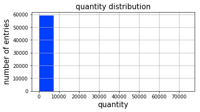

```python
plot_a_histogram('quantity')
```

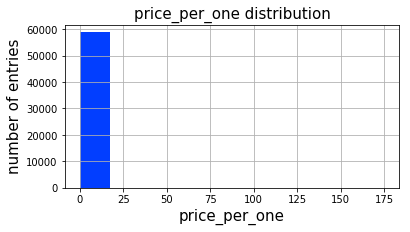

```python
plot_a_histogram('price_per_one')
```

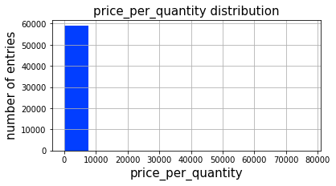

```python
plot_a_histogram('price_per_quantity')
```

- The histograms of the numerical data show that there are outliers for all categories. All numerical data categories are right skewed

*3.a.3 Evaluate the item prices*

- Determine how many items are `price_per_one` outliers

```python
# review data
purchases_clean.head(2)
```

|  | purchase_id | item_id | quantity | purchase_datetime | customer_id | loyalty_program | shop_id | purchase_date | price_per_one | price_per_quantity |
| --- | --- | --- | --- | --- | --- | --- | --- | --- | --- | --- |
| 0 | 538280 | 21873 | 11 | 2016-12-10 12:50:00 | 18427.0 | 0 | Shop 3 | 2016-12-10 | 0.42 | 4.62 |
| 2 | 540418 | 21873 | 1 | 2017-01-07 11:04:00 | 0.0 | 0 | Shop 0 | 2017-01-07 | 0.42 | 0.42 |

```python
# create a dictionary of percentiles
percentile_dict = [90, 95, 99]

# evaluate percentiles for categories
item_price_percentiles = np.percentile(purchases_clean['price_per_one'], percentile_dict)

for tile in range(0, len(percentile_dict)):
    print('top {}% of single priced items are {} or more'.format(100 - percentile_dict[tile],
                                                                item_price_percentiles[tile]))
```

```
top 10% of single priced items are 4.25 or more
top 5% of single priced items are 6.75 or more
top 1% of single priced items are 9.95 or more
```

```python
# query for high priced items, those in top 5% of price range
top_five_perc_item_percentile = item_price_percentiles[1]
top_five_perc_items = purchases_clean.query('price_per_one >= @top_five_perc_item_percentile')
top_five_perc_items.head()
```

|  | purchase_id | item_id | quantity | purchase_datetime | customer_id | loyalty_program | shop_id | purchase_date | price_per_one | price_per_quantity |
| --- | --- | --- | --- | --- | --- | --- | --- | --- | --- | --- |
| 1684 | 543193 | 22839 | 3 | 2017-02-04 12:18:00 | 19404.0 | 0 | Shop 13 | 2017-02-04 | 12.75 | 38.25 |
| 1687 | 544075 | 22839 | 15 | 2017-02-15 14:50:00 | 19835.0 | 0 | Shop 26 | 2017-02-15 | 12.75 | 191.25 |
| 1703 | 538753 | 22839 | 3 | 2016-12-14 11:29:00 | 20580.0 | 0 | Shop 19 | 2016-12-14 | 12.75 | 38.25 |
| 1709 | 539002 | 22839 | 1 | 2016-12-15 12:30:00 | 20206.0 | 0 | Shop 11 | 2016-12-15 | 12.75 | 12.75 |
| 1711 | 543555 | 22839 | 1 | 2017-02-10 10:18:00 | 23365.0 | 1 | Shop 0 | 2017-02-10 | 12.75 | 12.75 |

```python
# determine the number of high price per single item outliers, those in top 5% of price range
num_top_five_perc_items = top_five_perc_items['item_id'].nunique()
print('number of items in top 5% of price per single item: {}'.format(num_top_five_perc_items))
```

```
number of items in top 5% of price per single item: 233
```

*3.a.4 Group by `puchase_id` to evaluate the total price of purchases*

- Determine the average and median cost per total purchase
- Determine the total purchase outliers
  - Do the high purchases contain high `price_per_one` items?
  - Are the outlier purchases in the loyalty program or not?

*Determine the average and median purchase price*

```python
# create a table to determine the avg, median, and total cost of each purchase (based on purchase_id)
purchase_id_table = purchases_clean.pivot_table(index = 'purchase_id',
                                              values = 'price_per_quantity',
                                              aggfunc = 'sum').reset_index()
purchase_id_table.columns = ['purchase_id', 'total_purchase_cost']
purchase_id_table.head()
```

|  | purchase_id | total_purchase_cost |
| --- | --- | --- |
| 0 | 536365 | 62.80 |
| 1 | 536367 | 169.93 |
| 2 | 536368 | 48.45 |
| 3 | 536369 | 10.90 |
| 4 | 536370 | 644.57 |

```python
# evaluate the stats
purchase_id_table.describe()
```

|  | total_purchase_cost |
| --- | --- |
| count | 3516.000000 |
| mean | 308.285438 |
| std | 1457.399756 |
| min | 0.360000 |
| 25% | 71.015000 |
| 50% | 150.560000 |
| 75% | 283.122500 |
| max | 77182.560000 |

```python
#calculate the mean and median of the purchase prices
print('Average purchase price: ', (purchase_id_table['total_purchase_cost'].mean()).round(2))
print('Median purchase price: ', purchase_id_table['total_purchase_cost'].median())
diff_btwn_avg_med = purchase_id_table['total_purchase_cost'].mean() - purchase_id_table['total_purchase_cost'].median()
print('Difference between average and median purchase price: ', (diff_btwn_avg_med).round(2))
```

```
Average purchase price:  308.29
Median purchase price:  150.56
Difference between average and median purchase price:  157.73
```

*Determine the total purchase outliers*

```python
# calculate the percentiles
purchase_id_percentiles = np.percentile(purchase_id_table['total_purchase_cost'], percentile_dict)

for tile in range(0, len(percentile_dict)):
    print('top {}% of total purchase price is {:.2f} or more'.format(100 - percentile_dict[tile],
                                                                purchase_id_percentiles[tile]))
```

```
top 10% of total purchase price is 548.51 or more
top 5% of total purchase price is 866.27 or more
top 1% of total purchase price is 2451.17 or more
```

```python
# query for high total purchase price, those in top 5% of purchase range
top_five_perc_purch_price_percentile = purchase_id_percentiles[1]

top_five_perc_purch_prices = purchase_id_table.query('total_purchase_cost >= @top_five_perc_purch_price_percentile')
top_five_perc_purch_prices.head()
```

|  | purchase_id | total_purchase_cost |
| --- | --- | --- |
| 16 | 536387 | 2451.04 |
| 19 | 536390 | 1291.52 |
| 47 | 536477 | 2133.28 |
| 64 | 536532 | 1050.72 |
| 96 | 536576 | 1149.48 |

```python
# make a list of the purchase_ids in top 5% of purchase price
top_five_perc_purch_prices_list = list(top_five_perc_purch_prices['purchase_id'].unique())
print('number of purchases in top 5% percent of purchase cost: ', len(top_five_perc_purch_prices_list))
```

```
number of purchases in top 5% percent of purchase cost:  176
```

*Do the high purchases contain high `price_per_one` items?*

```python
# see how many top 5% priced items are in the top 5% purchase cost range
top_5_item_top_5_price_query = top_five_perc_items.query('purchase_id in @top_five_perc_purch_prices_list')
top_5_item_top_5_price_query.head()
```

|  | purchase_id | item_id | quantity | purchase_datetime | customer_id | loyalty_program | shop_id | purchase_date | price_per_one | price_per_quantity |
| --- | --- | --- | --- | --- | --- | --- | --- | --- | --- | --- |
| 1687 | 544075 | 22839 | 15 | 2017-02-15 14:50:00 | 19835.0 | 0 | Shop 26 | 2017-02-15 | 12.75 | 191.25 |
| 1737 | 541789 | 22839 | 7 | 2017-01-21 13:07:00 | 19767.0 | 0 | Shop 13 | 2017-01-21 | 12.75 | 89.25 |
| 3799 | 543099 | 21527 | 47 | 2017-02-03 12:00:00 | 22363.0 | 1 | Shop 24 | 2017-02-03 | 6.95 | 326.65 |
| 3825 | 537604 | 21527 | 1 | 2016-12-07 13:01:00 | 19167.0 | 0 | Shop 9 | 2016-12-07 | 6.95 | 6.95 |
| 3841 | 538664 | 21527 | 3 | 2016-12-13 15:46:00 | 20412.0 | 0 | Shop 13 | 2016-12-13 | 6.95 | 20.85 |

```python
print('number of items in top 5% of price per item that are in top 5% of purchase cost range: ',
      top_5_item_top_5_price_query['purchase_id'].nunique())
```

```
number of items in top 5% of price per item that are in top 5% of purchase cost range:  112
```

- Do the high purchases contain high `price_per_one` items?
  - yes, 112 of them out of 176

*Are the outlier purchases in the loyalty program or not?*

```python
# determine if the top 5% of purhases are part of the loyalty program
top_five_perc_purch_prices_loyalty_query = purchases_clean.query('purchase_id in @top_five_perc_purch_prices_list')
top_five_perc_purch_prices_loyalty_query.head()
```

|  | purchase_id | item_id | quantity | purchase_datetime | customer_id | loyalty_program | shop_id | purchase_date | price_per_one | price_per_quantity |
| --- | --- | --- | --- | --- | --- | --- | --- | --- | --- | --- |
| 8 | 544651 | 21873 | 71 | 2017-02-22 12:51:00 | 19373.0 | 0 | Shop 17 | 2017-02-22 | 0.42 | 29.82 |
| 19 | 540357 | 21873 | 107 | 2017-01-06 15:14:00 | 18772.0 | 0 | Shop 4 | 2017-01-06 | 0.42 | 44.94 |
| 23 | 537868 | 21873 | 23 | 2016-12-08 16:49:00 | 18112.0 | 0 | Shop 15 | 2016-12-08 | 0.42 | 9.66 |
| 25 | 540551 | 21873 | 1 | 2017-01-10 09:43:00 | 0.0 | 0 | Shop 0 | 2017-01-10 | 0.42 | 0.42 |
| 27 | 541827 | 21873 | 2 | 2017-01-21 17:05:00 | 0.0 | 0 | Shop 0 | 2017-01-21 | 0.42 | 0.84 |

```python
# calculate the number of high purchases (top 5%) in the loyalty program
num_top_five_perc_purch_prices_loyalty = top_five_perc_purch_prices_loyalty_query.query('loyalty_program == 1')['purchase_id'].nunique()
num_top_five_perc_purch_prices = top_five_perc_purch_prices_loyalty_query['purchase_id'].nunique()
perc = num_top_five_perc_purch_prices_loyalty / num_top_five_perc_purch_prices
print('{:.2%} of high purchases are in the loyalty program: {} out of {}'.format(perc, num_top_five_perc_purch_prices_loyalty, num_top_five_perc_purch_prices))
```

```
19.32% of high purchases are in the loyalty program: 34 out of 176
```

- Are the outlier purchases in the loyalty program or not?
  - yes 19%: 34 out of 176
  - being in the loyalty program doesnt mean you are buying more expensive purchases

*3.a.5 Evaluate the number of items per purchase*

- 3.a.5.i Create a table with the total number of items per purchase based on `purchase_id`
- 3.a.5.ii Use `describe()` to evaluate the mean and median of the items per purchase
- 3.a.5.iii Evaluate the percentiles
  - how many purchases contain a high number of items?
  - Are the purchases with a high number of items in the loyalty program or not?

*3.a.5.i Create a table with the total number of items per purchase based on `purchase_id`*

```python
# make a table counting all the items for each purchase
num_items_per_purchase_table = purchases_clean.pivot_table(index = 'purchase_id',
                                                    values = 'quantity', aggfunc = 'sum').reset_index()
num_items_per_purchase_table.columns = ('purchase_id', 'num_items_per_purchase')
num_items_per_purchase_table.head()
```

|  | purchase_id | num_items_per_purchase |
| --- | --- | --- |
| 0 | 536365 | 16 |
| 1 | 536367 | 68 |
| 2 | 536368 | 11 |
| 3 | 536369 | 2 |
| 4 | 536370 | 404 |

*3.a.5.ii Use `describe()` to evaluate the mean and median of the items per purchase*

```python
# evaluate the stats
num_items_per_purchase_table.describe()
```

|  | num_items_per_purchase |
| --- | --- |
| count | 3516.000000 |
| mean | 229.507395 |
| std | 1328.311494 |
| min | 1.000000 |
| 25% | 42.000000 |
| 50% | 98.000000 |
| 75% | 208.000000 |
| max | 74214.000000 |

```python
#calculate the mean and median of the number of items per purchase
print('Average number of items purchased: ', (num_items_per_purchase_table['num_items_per_purchase'].mean()).round(0))
print('Median number of items purchased: ', num_items_per_purchase_table['num_items_per_purchase'].median().round(0))
diff_btwn_avg_med = num_items_per_purchase_table['num_items_per_purchase'].mean() - num_items_per_purchase_table['num_items_per_purchase'].median()
print('Difference between average and median number of items per purchase: ', (diff_btwn_avg_med).round(0))
```

```
Average number of items purchased:  230.0
Median number of items purchased:  98.0
Difference between average and median number of items per purchase:  132.0
```

*3.a.5.iii Evaluate the percentiles*

- how many purchases contain a high number of items?
- Are the purchases with a high number of items in the loyalty program or not?

```python
# calculate the percentiles
number_items_per_purchase_percentiles = np.percentile(num_items_per_purchase_table['num_items_per_purchase'], percentile_dict)

for tile in range(0, len(percentile_dict)):
    print('top {}% of total items per purchase are {:.2f} or more items'.format(100 - percentile_dict[tile],
                                                                number_items_per_purchase_percentiles[tile].round(0)))
```

```
top 10% of total items per purchase are 431.00 or more items
top 5% of total items per purchase are 669.00 or more items
top 1% of total items per purchase are 2144.00 or more items
```

*how many purchases contain a high number of items?*

```python
# query for the top 5% of items purchased
top_5_perc_num_items_purchased = number_items_per_purchase_percentiles[1]
top_5_perc_num_items_per_purchase_query = num_items_per_purchase_table.query('num_items_per_purchase >= @top_5_perc_num_items_purchased')
top_5_perc_num_items_per_purchase_query.head()
```

|  | purchase_id | num_items_per_purchase |
| --- | --- | --- |
| 16 | 536387 | 1244 |
| 19 | 536390 | 1238 |
| 41 | 536437 | 998 |
| 47 | 536477 | 993 |
| 64 | 536532 | 1380 |

```python
# make a list of the purchases with the top 5% number of items per transaction >= 669
top_5_perc_num_items_per_purchase_purchase_ids_list = list(top_5_perc_num_items_per_purchase_query['purchase_id'].unique())
print('number of purchases in the top 5% of quantity purchased: ', len(top_5_perc_num_items_per_purchase_purchase_ids_list))
```

```
number of purchases in the top 5% of quantity purchased:  176
```

*Are the purchases with a high number of items in the loyalty program or not?*

```python
# determine if the top 5% of number of items purchased are part of the loyalty program
top_5_perc_num_items_per_purchase_loyalty_query = purchases_clean.query('purchase_id in @top_5_perc_num_items_per_purchase_purchase_ids_list')
top_5_perc_num_items_per_purchase_loyalty_query.head(2)
```

|  | purchase_id | item_id | quantity | purchase_datetime | customer_id | loyalty_program | shop_id | purchase_date | price_per_one | price_per_quantity |
| --- | --- | --- | --- | --- | --- | --- | --- | --- | --- | --- |
| 4 | 541566 | 21873 | 35 | 2017-01-19 11:50:00 | 23401.0 | 1 | Shop 22 | 2017-01-19 | 0.42 | 14.70 |
| 8 | 544651 | 21873 | 71 | 2017-02-22 12:51:00 | 19373.0 | 0 | Shop 17 | 2017-02-22 | 0.42 | 29.82 |

```python
# calculate the number of purachases with high number of items (top 5%) in the loyalty program
num_top_5_perc_num_items_per_purchase_loyalty = top_5_perc_num_items_per_purchase_loyalty_query.query('loyalty_program == 1')['purchase_id'].nunique()
num_top_5_perc_num_items_per_purchase = top_5_perc_num_items_per_purchase_loyalty_query['purchase_id'].nunique()
perc = num_top_5_perc_num_items_per_purchase_loyalty / num_top_5_perc_num_items_per_purchase
print('{:.2%} of purchases with high number of items purchased are in the loyalty program: {} out of {}'.format(perc, num_top_5_perc_num_items_per_purchase_loyalty, num_top_5_perc_num_items_per_purchase))
```

```
23.30% of purchases with high number of items purchased are in the loyalty program: 41 out of 176
```

*3.b Process outliers*

- decide on outlier cut off if approriate and remove them from further analysis
- *It is apporpriate to remove 5-10% of outliers, I will be removing the top 5% of total purchase price outliers and top 5% of purchases with high number or purchased itesm, this removes outliers while still being conservative in terms of data removal*

```python
# remove the top 5 percent of purchases with high total purchase cost
purchases_processed_tmp = purchases_clean.query('purchase_id not in @top_five_perc_purch_prices_list')

# remove the top 5 percent of purchases with high number of items purchased
purchases_processed = purchases_processed_tmp.query('purchase_id not in @top_5_perc_num_items_per_purchase_purchase_ids_list')
display(purchases_processed.info())
display(purchases_processed.describe())
```

```
<class 'pandas.core.frame.DataFrame'>
Int64Index: 48059 entries, 0 to 104300
Data columns (total 10 columns):
 #   Column              Non-Null Count  Dtype
---  ------              --------------  -----
 0   purchase_id         48059 non-null  object
 1   item_id             48059 non-null  object
 2   quantity            48059 non-null  int64
 3   purchase_datetime   48059 non-null  datetime64[ns]
 4   customer_id         48059 non-null  object
 5   loyalty_program     48059 non-null  int64
 6   shop_id             48059 non-null  object
 7   purchase_date       48059 non-null  datetime64[ns]
 8   price_per_one       48059 non-null  float64
 9   price_per_quantity  48059 non-null  float64
dtypes: datetime64[ns](2), float64(2), int64(2), object(4)
memory usage: 4.0+ MB
```

```
None
```

|  | quantity | loyalty_program | price_per_one | price_per_quantity |
| --- | --- | --- | --- | --- |
| count | 48059.000000 | 48059.000000 | 48059.000000 | 48059.000000 |
| mean | 8.922803 | 0.287105 | 2.224689 | 12.575004 |
| std | 17.400494 | 0.452416 | 3.183278 | 22.784962 |
| min | 1.000000 | 0.000000 | 0.030000 | 0.030000 |
| 25% | 2.000000 | 0.000000 | 0.850000 | 3.300000 |
| 50% | 5.000000 | 0.000000 | 1.450000 | 8.150000 |
| 75% | 11.000000 | 1.000000 | 2.550000 | 13.750000 |
| max | 647.000000 | 1.000000 | 145.000000 | 833.750000 |

*3.c Quality check of loyalty program*

- confirm that purchases are made as a loylaty program member or not - not a mix
  - 3.c.1 Use `groupby()` `purchase_id` to get the average values of the loyalty program column
    - if there are percentages, then there is a mix of membership in those purchases
  - 3.c.2 evaluate the unique values of the quality check

*3.c.1 Use `groupby()` `purchase_id` to get the average values of the loyalty program column*

- if there are percentages, then there is a mix of membership in those purchases

```python
# confirm that purchases are made as a loylaty program member or not - not a mix
quality_check_loyalty_program = purchases_processed.groupby('purchase_id')['loyalty_program'].mean()
quality_check_loyalty_program.head()
```

```
purchase_id
536365    1
536367    0
536368    0
536369    0
536370    0
Name: loyalty_program, dtype: int64
```

*3.c.2 evaluate the unique values of the quality check*

```python
# review the unique values of the loyalty program average
print('unique values from quality check of the loyalty program: ', quality_check_loyalty_program.unique(), '; percentages indicate an error')
```

```
unique values from quality check of the loyalty program:  [1 0] ; percentages indicate an error
```

- There are no purchases that contain an error of having a mix of loyalty and non-loyalty member status

*3.d Visualize the data*

- create queries or use `groupby()` to plot the following graphs
  - 3.d.1 evaluate each membership group numerical data using the describe() method
  - 3.d.2 plot histograms of the total purchase prices per membership
  - 3.d.3 plot bar graphs of the total and average purchase prices per customer status
  - 3.d.4 plot bar graphs of total purchase prices per membership per shop
  - 3.d.5 plot bar graphs of average purchase prices per membership per shop
  - 3.d.6 plot bar graphs of the total and average purchase prices per day per customer status
  - 3.d.7 plot histograms of the number of items purchased per membership
  - 3.d.8 plot bar graphs of the total and average number of items purchased per customer status
  - 3.d.9 plot bar graph of number of items purchased per store based on customer status
  - 3.d.10 plot bar graph of the average number of items purchased per store based on customer status
  - 3.d.11 plot bar graphs of the total and average number of items purchased per date per customer status
  - 3.d.12 plot bar graphs of the total and average number of purchases per customer status

*3.d.1 evaluate each membership group numerical data using the describe() method*

```python
# create queries for each membership status
loyalty_members = purchases_processed.query('loyalty_program == 1')
non_loyalty_members = purchases_processed.query('loyalty_program == 0')
print('stats of loyalty members:')
display(loyalty_members.describe())
print('stats of non loyalty members:')
display(non_loyalty_members.describe())
```

```
stats of loyalty members:
```

|  | quantity | loyalty_program | price_per_one | price_per_quantity |
| --- | --- | --- | --- | --- |
| count | 13798.000000 | 13798.0 | 13798.000000 | 13798.000000 |
| mean | 8.992028 | 1.0 | 2.244337 | 12.480491 |
| std | 17.591355 | 0.0 | 3.377640 | 22.611784 |
| min | 1.000000 | 1.0 | 0.030000 | 0.060000 |
| 25% | 2.000000 | 1.0 | 0.850000 | 3.300000 |
| 50% | 5.000000 | 1.0 | 1.450000 | 7.650000 |
| 75% | 11.000000 | 1.0 | 2.550000 | 13.750000 |
| max | 599.000000 | 1.0 | 125.000000 | 726.750000 |

```
stats of non loyalty members:
```

|  | quantity | loyalty_program | price_per_one | price_per_quantity |
| --- | --- | --- | --- | --- |
| count | 34261.000000 | 34261.0 | 34261.000000 | 34261.000000 |
| mean | 8.894924 | 0.0 | 2.216777 | 12.613067 |
| std | 17.323214 | 0.0 | 3.101580 | 22.854554 |
| min | 1.000000 | 0.0 | 0.030000 | 0.030000 |
| 25% | 2.000000 | 0.0 | 0.850000 | 3.300000 |
| 50% | 5.000000 | 0.0 | 1.450000 | 8.250000 |
| 75% | 11.000000 | 0.0 | 2.550000 | 13.750000 |
| max | 647.000000 | 0.0 | 145.000000 | 833.750000 |

```python
num_loyalty_purchases_in_processed_data = loyalty_members['purchase_id'].nunique()
num_non_loyalty_purchases_in_processed_data = non_loyalty_members['purchase_id'].nunique()
print('number of loyalty purchases: ', num_loyalty_purchases_in_processed_data)
print('number of non-loyalty purchases: ', num_non_loyalty_purchases_in_processed_data)
total_purchases_in_processed_data = purchases_processed['purchase_id'].nunique()
perc_loyalty_purchases = num_loyalty_purchases_in_processed_data / total_purchases_in_processed_data
print('{:.2%} of purchases made by loyalty members'.format(perc_loyalty_purchases))
```

```
number of loyalty purchases:  1031
number of non-loyalty purchases:  2265
31.28% of purchases made by loyalty members
```

- There are 1031 purchases in the loyalty program and 2265 that were not
  - 31% of purchases were made by loyalty members
- The means and medians for numerical data are still different but I took a more conservative stance on removing outliers
- The statistical trends are similar for both groups, i.e. the min, max, 25%, 50%, 75% values are similar

### Visualize data related to the purchase prices

*3.d.2 plot histograms of the total purchase prices per membership*

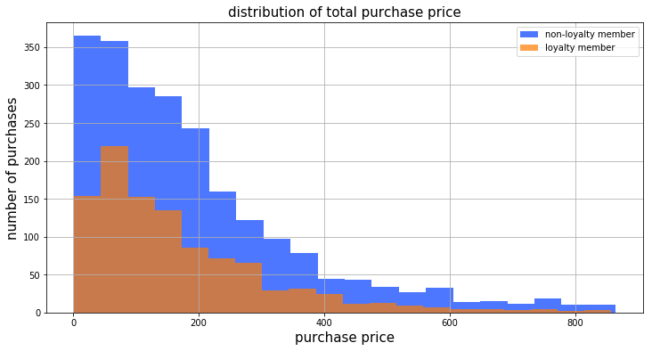

```python
# groupby purhcase_id, calculate the total cost per purchase per membership status
loyalty_members_purchase_prices = loyalty_members.groupby('purchase_id')['price_per_quantity'].sum()
non_loyalty_members_purchase_prices = non_loyalty_members.groupby('purchase_id')['price_per_quantity'].sum()

# plot histograms
non_loyalty_members_purchase_prices.hist(alpha = 0.7, bins = 20, label = 'non-loyalty member', figsize = (12, 6))
loyalty_members_purchase_prices.hist(alpha = 0.7, bins = 20, label = 'loyalty member')
plt.title('distribution of total purchase price', size = 15)
plt.xlabel('purchase price', size = 15)
plt.ylabel('number of purchases', size = 15)
plt.legend()
plt.show()
```

- the total purchase price for both statuses follow the same trend, most puchases cost under 200 and the data is right skewed, suggesting there are still some outliers

*3.d.3 plot bar graphs of the total and average purchase prices per customer status*

```python
# create a table of the total and average purchase prices per shop
purchase_price_per_shop = purchases_processed.pivot_table(index = 'shop_id', columns = 'loyalty_program',
                                 values = 'price_per_quantity', aggfunc = ['sum', 'mean']).reset_index()
# rename columns
purchase_price_per_shop.columns = ('shop_id', 'non_loyalty_prices_total', 'loyalty_prices_total',
                                  'non_loyalty_prices_avg', 'loyalty_prices_avg')
# review table
purchase_price_per_shop.head()
```

|  | shop_id | non_loyalty_prices_total | loyalty_prices_total | non_loyalty_prices_avg | loyalty_prices_avg |
| --- | --- | --- | --- | --- | --- |
| 0 | Shop 0 | 51380.37 | 6851.52 | 5.879434 | 12.664547 |
| 1 | Shop 1 | 12122.21 | 5933.67 | 13.439257 | 9.493872 |
| 2 | Shop 10 | 12322.17 | 4210.28 | 14.147153 | 11.409973 |
| 3 | Shop 11 | 14348.86 | 7666.07 | 17.143202 | 12.207118 |
| 4 | Shop 12 | 9762.80 | 5621.46 | 13.692567 | 15.879831 |

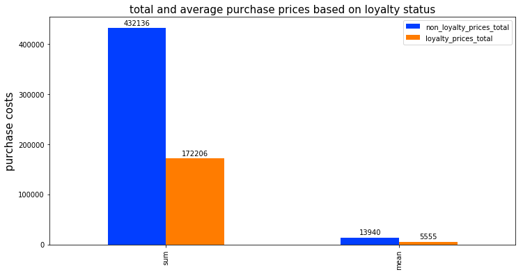

```python
# plot bar graphs of the total and mean purchase prices per customer status
purchase_price_per_shop_graph = purchase_price_per_shop[['non_loyalty_prices_total', 'loyalty_prices_total']].agg(['sum', 'mean']).plot(kind = 'bar', figsize = (12, 6))
plt.title('total and average purchase prices based on loyalty status', size = 15)
plt.ylabel('purchase costs', size = 15)

# label bars with data
for bar in purchase_price_per_shop_graph.patches:
    purchase_price_per_shop_graph.annotate(format(bar.get_height(), '.0f'),
                xy=(bar.get_x() + bar.get_width() / 2, bar.get_height()),
                ha = 'center',
                va = 'center',
                xytext = (0, 7),
                textcoords = 'offset points')

plt.show()
```

- Non-loyalty members make higher priced purchases total and on average compared to loyalty members

## Reviewer's commentary

**Remarks and recommendations📌:** For the above histogram you look at the total prices and conclude that non-loyalty members make higher priced purchases. But here you should be careful because it may be not because of higher priced purchases but simply because of the higher number of customers that are not in the loyalty program (which is indeed the case). It is better to work with means/medians when you compare groups.

*3.d.4 plot bar graphs of total purchase prices per membership per shop*

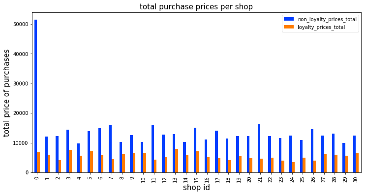

```python
# plot bar graph of total purchase prices per shop based on loyalty status
purchase_price_per_shop[['non_loyalty_prices_total', 'loyalty_prices_total']].plot(kind = 'bar', figsize = (12, 6))
plt.title('total purchase prices per shop', size = 15)
plt.xlabel('shop id', size = 15)
plt.ylabel('total price of purchases', size = 15)
plt.show()
```

- non-loyalty members make larger priced purchases compared to loyalty members

*3.d.5 plot bar graphs of average purchase prices per membership per shop*

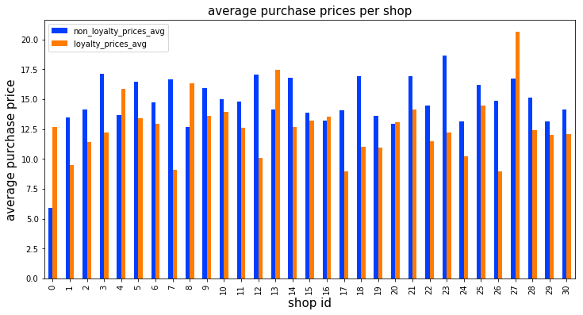

```python
# plot bar graph of average purchase prices per shop based on loyalty status
purchase_price_per_shop[['non_loyalty_prices_avg', 'loyalty_prices_avg']].plot(kind = 'bar', figsize = (12, 6))
plt.title('average purchase prices per shop', size = 15)
plt.xlabel('shop id', size = 15)
plt.ylabel('average purchase price', size = 15)
plt.show()
```

- For the majority of shops, non-loyalty customers on average make larger priced purchases

*3.d.6 plot bar graphs of the total and average purchase prices per day per customer status*

```python
# create a table of the total and average purchase prices per date
purchase_price_per_date = purchases_processed.pivot_table(index = 'purchase_date', columns = 'loyalty_program',
                                 values = 'price_per_quantity', aggfunc = ['sum', 'mean'], fill_value = 0).reset_index()
# rename columns
purchase_price_per_date.columns = ('purchase_date', 'non_loyalty_prices_total', 'loyalty_prices_total',
                                  'non_loyalty_prices_avg', 'loyalty_prices_avg')
# review table
purchase_price_per_date.head()
```

|  | purchase_date | non_loyalty_prices_total | loyalty_prices_total | non_loyalty_prices_avg | loyalty_prices_avg |
| --- | --- | --- | --- | --- | --- |
| 0 | 2016-12-01 | 12577.80 | 4749.27 | 14.260544 | 13.530684 |
| 1 | 2016-12-02 | 10539.45 | 7332.67 | 16.017401 | 14.128459 |
| 2 | 2016-12-03 | 6493.60 | 2814.85 | 16.481218 | 14.972606 |
| 3 | 2016-12-05 | 8686.41 | 2929.68 | 10.207297 | 7.750476 |
| 4 | 2016-12-06 | 7147.47 | 4887.65 | 12.948315 | 9.345411 |

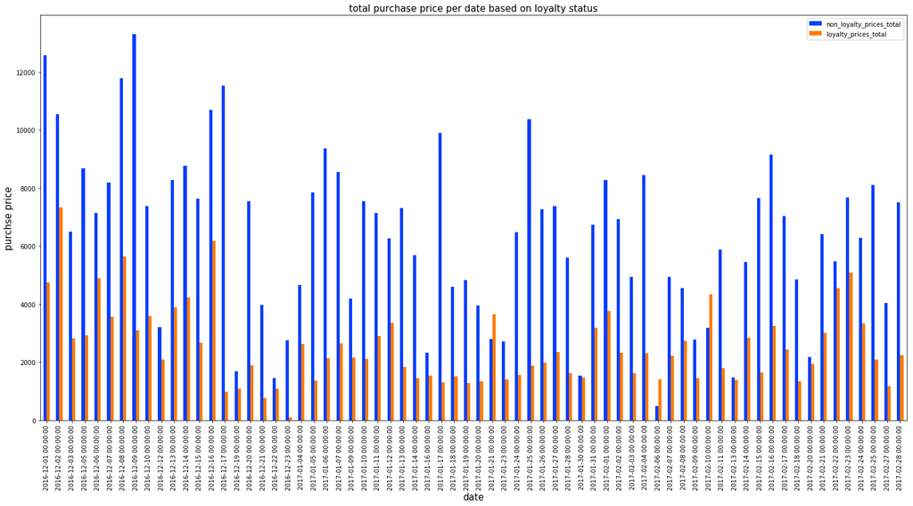

```python
# graph the total purchase price per date per customer status
total_price_per_date_graph = purchase_price_per_date[['non_loyalty_prices_total', 'loyalty_prices_total']].plot(kind = 'bar', figsize = (25, 12))
plt.title('total purchase price per date based on loyalty status', size = 15)
plt.xlabel('date', size = 15)
plt.ylabel('purchse price', size = 15)
total_price_per_date_graph.set_xticklabels(purchase_price_per_date['purchase_date'], rotation = 90)
plt.show()
```

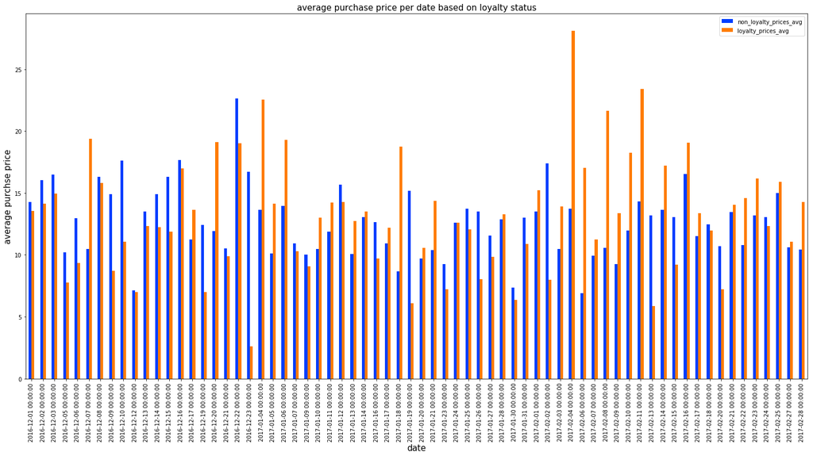

```python
# graph the average purchase price per date per customer status
average_price_per_date_graph = purchase_price_per_date[['non_loyalty_prices_avg', 'loyalty_prices_avg']].plot(kind = 'bar', figsize = (25, 12))
plt.title('average purchase price per date based on loyalty status', size = 15)
plt.xlabel('date', size = 15)
plt.ylabel('average purchse price', size = 15)
average_price_per_date_graph.set_xticklabels(purchase_price_per_date['purchase_date'], rotation = 90)
plt.show()
```

- non-loyalty members make larger purchases total per day
- however on average the purchase price per day varies day to day based on loyalty status, some days loyalty members make larger purchases on average, sometimes the non-loyalty members make larger purchases on average

### Visualize data related to the purchased items

*3.d.7 plot histograms of the number of items purchased per membership*

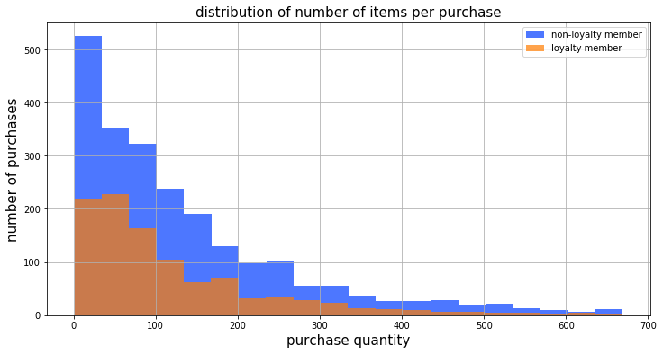

```python
# groupby purhcase_id, calculate the total number of items per purchase per membership status
loyalty_members_purchase_quantity = loyalty_members.groupby('purchase_id')['quantity'].sum()
non_loyalty_members_purchase_quantity = non_loyalty_members.groupby('purchase_id')['quantity'].sum()

# plot histograms
non_loyalty_members_purchase_quantity.hist(alpha = 0.7, bins = 20, label = 'non-loyalty member', figsize = (12, 6))
loyalty_members_purchase_quantity.hist(alpha = 0.7, bins = 20, label = 'loyalty member')
plt.title('distribution of number of items per purchase', size = 15)
plt.xlabel('purchase quantity', size = 15)
plt.ylabel('number of purchases', size = 15)
plt.legend()
plt.show()
```

- the number of items per purchase for both statuses follow the same trend, most puchases have 200 or less items and the data is right skewed, suggesting there are still some outliers

*3.d.8 plot bar graphs of the total and average number of items purchased per customer status*

```python
# create a table to get the quantity of items purchased per store
quantity_per_shop = purchases_processed.pivot_table(index = 'shop_id', columns = 'loyalty_program',
                                                  values = 'quantity', aggfunc = ['sum', 'mean']).reset_index()
quantity_per_shop.columns = ('shop_id', 'non_loyalty_quantity', 'loyalty_quantity',
                             'avg_non_loyalty_quantity', 'avg_loyalty_quantity')
quantity_per_shop.head()
```

|  | shop_id | non_loyalty_quantity | loyalty_quantity | avg_non_loyalty_quantity | avg_loyalty_quantity |
| --- | --- | --- | --- | --- | --- |
| 0 | Shop 0 | 36281 | 4633 | 4.151619 | 8.563771 |
| 1 | Shop 1 | 10084 | 4908 | 11.179601 | 7.852800 |
| 2 | Shop 10 | 9094 | 2730 | 10.440873 | 7.398374 |
| 3 | Shop 11 | 9856 | 5573 | 11.775388 | 8.874204 |
| 4 | Shop 12 | 8172 | 3798 | 11.461431 | 10.728814 |

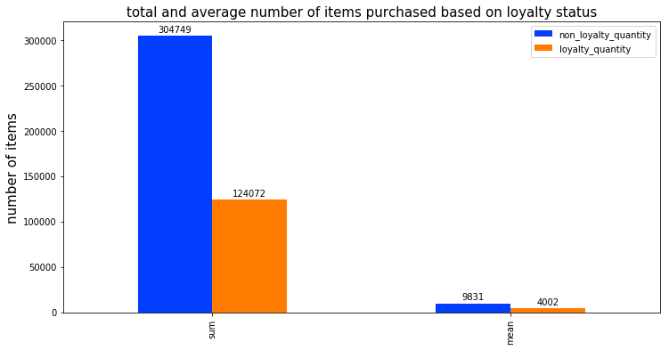

```python
# plot bar graphs of the total and average number of items purchased per customer status
quantity_per_shop_graph = quantity_per_shop[['non_loyalty_quantity', 'loyalty_quantity']].agg(['sum', 'mean']).plot(kind = 'bar', figsize = (12, 6))
plt.title('total and average number of items purchased based on loyalty status', size = 15)
plt.ylabel('number of items', size = 15)

# label bars with data
for bar in quantity_per_shop_graph.patches:
    quantity_per_shop_graph.annotate(format(bar.get_height(), '.0f'),
                xy=(bar.get_x() + bar.get_width() / 2, bar.get_height()),
                ha = 'center',
                va = 'center',
                xytext = (0, 7),
                textcoords = 'offset points')

plt.show()
```

- Non-loyalty members purchase more items total and on average compared to loyalty members

*3.d.9 plot bar graph of number of items purchased per store based on customer status*

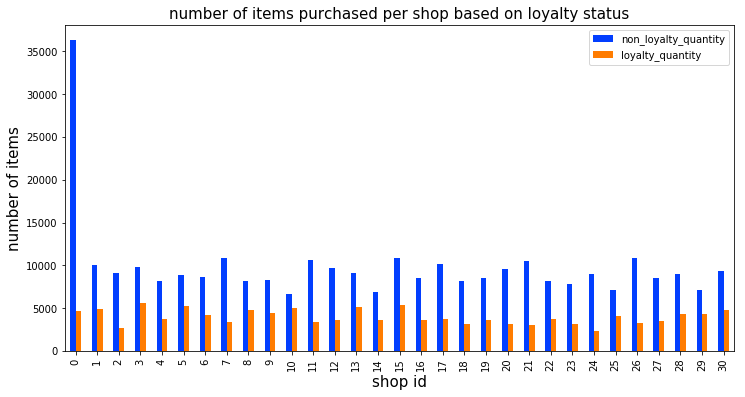

```python
# plot bar graph of number of items purchased per shop based on customer status
quantity_per_shop[['non_loyalty_quantity', 'loyalty_quantity']].plot(kind = 'bar', figsize = (12, 6))
plt.title('number of items purchased per shop based on loyalty status', size = 15)
plt.xlabel('shop id', size = 15)
plt.ylabel('number of items', size = 15)
plt.show()
```

- Non-loyalty members purchase more items per store compared to loyalty members

*3.d.10 plot bar graph of the average number of items purchased per store based on customer status*

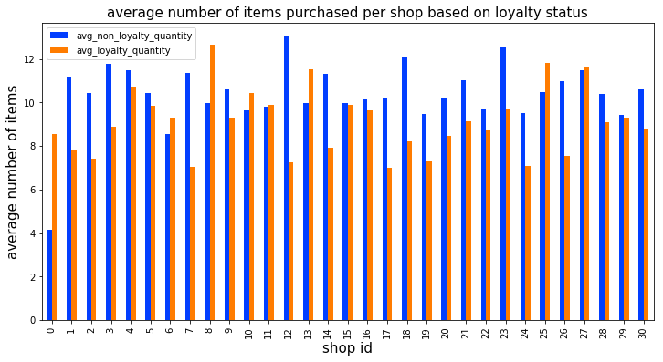

```python
# plot bar graph of average number of items purchased per shop based on customer status
quantity_per_shop[['avg_non_loyalty_quantity', 'avg_loyalty_quantity']].plot(kind = 'bar', figsize = (12, 6))
plt.title('average number of items purchased per shop based on loyalty status', size = 15)
plt.xlabel('shop id', size = 15)
plt.ylabel('average number of items', size = 15)
plt.show()
```

- On average non-loyalty members purchase more items compared to loyalty members

*3.d.11 plot bar graphs of the total and average number of items purchased per date per customer status*

```python
# create a table of the total and average number of items purchased per date
num_items_per_date = purchases_processed.pivot_table(index = 'purchase_date', columns = 'loyalty_program',
                                 values = 'quantity', aggfunc = ['sum', 'mean'], fill_value = 0).reset_index()
# rename columns
num_items_per_date.columns = ('purchase_date', 'non_loyalty_items_total', 'loyalty_items_total',
                                  'non_loyalty_items_avg', 'loyalty_items_avg')
# review table
num_items_per_date.head()
```

|  | purchase_date | non_loyalty_items_total | loyalty_items_total | non_loyalty_items_avg | loyalty_items_avg |
| --- | --- | --- | --- | --- | --- |
| 0 | 2016-12-01 | 8065 | 2873 | 9.143991 | 8.185185 |
| 1 | 2016-12-02 | 7695 | 4324 | 11.694529 | 8.331407 |
| 2 | 2016-12-03 | 3992 | 1584 | 10.131980 | 8.425532 |
| 3 | 2016-12-05 | 5872 | 2105 | 6.900118 | 5.568783 |
| 4 | 2016-12-06 | 5246 | 3833 | 9.503623 | 7.328872 |

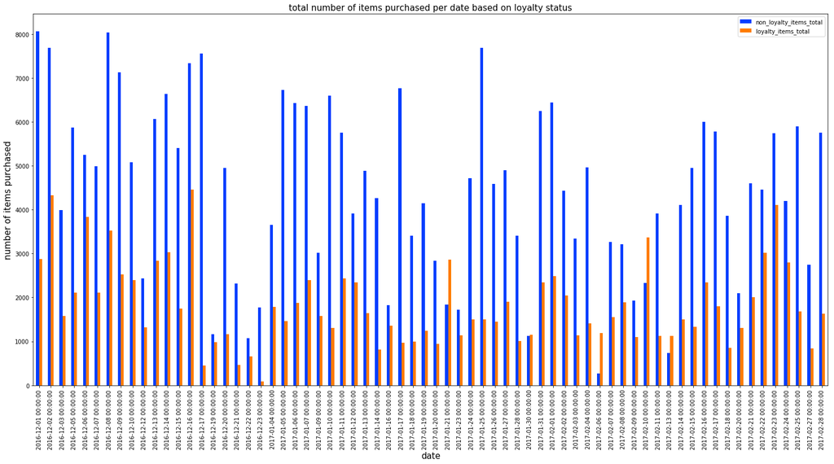

```python
# plot graph of total number of items purchased per date per customer status
total_items_per_date_graph = num_items_per_date[['non_loyalty_items_total', 'loyalty_items_total']].plot(kind = 'bar', figsize = (25, 12))
plt.title('total number of items purchased per date based on loyalty status', size = 15)
plt.xlabel('date', size = 15)
plt.ylabel('number of items purchased', size = 15)
total_items_per_date_graph.set_xticklabels(num_items_per_date['purchase_date'], rotation = 90)
plt.show()
```

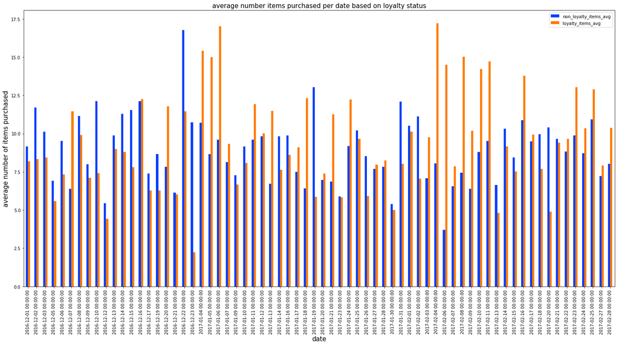

```python
# plot graph of average number of items purchased per date per customer status
average_items_per_date_graph = num_items_per_date[['non_loyalty_items_avg', 'loyalty_items_avg']].plot(kind = 'bar', figsize = (25, 12))
plt.title('average number items purchased per date based on loyalty status', size = 15)
plt.xlabel('date', size = 15)
plt.ylabel('average number of items purchased', size = 15)
average_items_per_date_graph.set_xticklabels(num_items_per_date['purchase_date'],
                                           rotation = 90)
plt.show()
```

- non-loyalty members purchase more items total per day
- however on average the number of items purchased per day varies day to day based on loyalty status, some days loyalty members purchase more items on average, sometimes the non-loyalty members purchase more itesm on average

*3.d.12 plot bar graphs of the total and average number of purchases per customer status*

```python
# review data
purchases_processed.head(2)
```

|  | purchase_id | item_id | quantity | purchase_datetime | customer_id | loyalty_program | shop_id | purchase_date | price_per_one | price_per_quantity |
| --- | --- | --- | --- | --- | --- | --- | --- | --- | --- | --- |
| 0 | 538280 | 21873 | 11 | 2016-12-10 12:50:00 | 18427.0 | 0 | Shop 3 | 2016-12-10 | 0.42 | 4.62 |
| 2 | 540418 | 21873 | 1 | 2017-01-07 11:04:00 | 0.0 | 0 | Shop 0 | 2017-01-07 | 0.42 | 0.42 |

```python
# create queries of membership status
loyalty_query = purchases_processed.query('loyalty_program == 1')
non_loyalty_query = purchases_processed.query('loyalty_program == 0')

# create tables with number of purchases per shop based on queries
loyalty_purchases_per_shop = loyalty_query.groupby('shop_id')['purchase_id'].nunique().reset_index()
# rename columns
loyalty_purchases_per_shop.columns = ('shop_id', 'loyalty_purchases')
# review table
display(loyalty_purchases_per_shop.head())

# create tables with number of purchases per shop based on queries
non_loyalty_purchases_per_shop = non_loyalty_query.groupby('shop_id')['purchase_id'].nunique().reset_index()
# rename columns
non_loyalty_purchases_per_shop.columns = ('shop_id', 'non_loyalty_purchases')
# review table
display(non_loyalty_purchases_per_shop.head())
```

|  | shop_id | loyalty_purchases |
| --- | --- | --- |
| 0 | Shop 0 | 34 |
| 1 | Shop 1 | 34 |
| 2 | Shop 10 | 31 |
| 3 | Shop 11 | 42 |
| 4 | Shop 12 | 30 |

|  | shop_id | non_loyalty_purchases |
| --- | --- | --- |
| 0 | Shop 0 | 316 |
| 1 | Shop 1 | 76 |
| 2 | Shop 10 | 61 |
| 3 | Shop 11 | 71 |
| 4 | Shop 12 | 58 |

```python
# merge the tables
purchases_per_shop = pd.merge(non_loyalty_purchases_per_shop,
                              loyalty_purchases_per_shop,
                              on = 'shop_id')
```

```python
# review the merged tables
purchases_per_shop.head()
```

|  | shop_id | non_loyalty_purchases | loyalty_purchases |
| --- | --- | --- | --- |
| 0 | Shop 0 | 316 | 34 |
| 1 | Shop 1 | 76 | 34 |
| 2 | Shop 10 | 61 | 31 |
| 3 | Shop 11 | 71 | 42 |
| 4 | Shop 12 | 58 | 30 |

```python
purchases_per_shop['non_loyalty_purchases'].mean()
purchases_per_shop['loyalty_purchases'].mean()
```

```
33.25806451612903
```

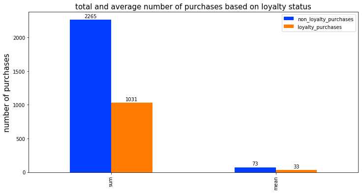

```python
# plot bar graphs of the total and average number of purchases per customer status
purchases_per_shop_graph = purchases_per_shop[['non_loyalty_purchases', 'loyalty_purchases']].agg(['sum', 'mean']).plot(kind = 'bar', figsize = (12, 6))
plt.title('total and average number of purchases based on loyalty status', size = 15)
plt.ylabel('number of purchases', size = 15)

# label bars with data
for bar in purchases_per_shop_graph.patches:
    purchases_per_shop_graph.annotate(format(bar.get_height(), '.0f'),
                xy=(bar.get_x() + bar.get_width() / 2, bar.get_height()),
                ha = 'center',
                va = 'center',
                xytext = (0, 7),
                textcoords = 'offset points')

plt.show()
```

- Non-loyalty members make more purchases total and on average compared to loyalty members
- Non-loyalty members have more transactions per purchase compared to loyalty members

# Step 3 Conclusion

# Carry out exploratory data analysis (EDA)

*Actions Performed*

*Used the merged table `purchases_clean` for analysis

# Step 4. Test Hypothesis

*4.a Evaluate hypothesis: Customers who participate in the loyalty program make larger purchases by price on average*

*4.a.1 obtain list/query of the purchase prices per group*

```python
# create a list of the total cost of purchases made by each membership status
loyalty_total_puchase_prices_list = list(loyalty_members_purchase_prices)
non_loyalty_total_puchase_prices_list = list(non_loyalty_members_purchase_prices)
```

*4.a.2 evaluate the dispersion of data sets*

- if the dispersion is similar then the parameter `equal_var=True`
- if the dispersion is not similar then the parameter `equal_var=False`

```python
# examine the dispersion of the groups
print('Dispersion:')
print('loyalty members purchase price:', np.var(loyalty_total_puchase_prices_list))
print('non loyalty members purchase price:', np.var(non_loyalty_total_puchase_prices_list))
```

```
Dispersion:
loyalty members purchase price: 21126.84867685813
non loyalty members purchase price: 28478.999144720947
```

*4.a.3 Test Hypothesis*

- Null hypothesis: The average purchase prices are statistically the same for all customers regardless of participation in loyalty program
- Alternative hypothesis: The average purchase prices are statistically different for customers that do versus those that do not participate in the loyalty program

```python
# Test hypothesis
alpha = 0.05 # 5% as the critical statistical significance level

results = st.ttest_ind(loyalty_total_puchase_prices_list,
                       non_loyalty_total_puchase_prices_list,
                       equal_var = False)

print('p-value: ', results.pvalue)

if results.pvalue < alpha:
    print('Reject the null hypothesis, the alternative hypothesis is true: The average purchase prices are statistically different for customers that do versus those that do not participate in the loyalty program')
else:
    print('Can not reject the null hypothesis, the null hypothesis is true: The average purchase prices are statistically the same for all customers regardless of participation in loyalty program')
```

```
p-value:  3.748986856510029e-05
Reject the null hypothesis, the alternative hypothesis is true: The average purchase prices are statistically different for customers that do versus those that do not participate in the loyalty program
```

*4.a Conclusion*

*Evaluate hypothesis: Customers who participate in the loyalty program make larger purchases by price on average*

- Null hypothesis: The average purchase prices are statistically the same for all customers regardless of participation in loyalty program
- Alternative hypothesis: The average purchase prices are statistically different for customers that do versus those that do not participate in the loyalty program

*Results*

- The null hypothesis is rejected and the alternative hypothesis is true: The average purchase prices are statistically different for customers that do versus those that do not participate in the loyalty program
- The average purchase price is different between loyalty and non-loyalty members, however based on the bar graphs non-loyalty members make larger purchases by price compared to loyalty members

*4.b Evaluate hypothesis: Customers who participate in the loyalty program buy more items on average*

*4.b.1 obtain list/query of the number of items purchased per group*

```python
# create a list of the total items purchased per purchase made by each membership status
loyalty_total_items_purchased_list = list(loyalty_members_purchase_quantity)
non_loyalty_total_items_purchased_list = list(non_loyalty_members_purchase_quantity)
```

*4.b.2 evaluate the dispersion of data sets*

- if the dispersion is similar then the parameter `equal_var=True`
- if the dispersion is not similar then the parameter `equal_var=False`

```python
# examine the dispersion of the groups
print('Dispersion:')
print('loyalty members items purchased per purchase:', np.var(loyalty_total_items_purchased_list))
print('non loyalty members items purchased per purchase:', np.var(non_loyalty_total_items_purchased_list))
```

```
Dispersion:
loyalty members items purchased per purchase: 13901.181204202223
non loyalty members items purchased per purchase: 17295.734764849494
```

*4.b.3 Test Hypothesis*

- Null hypothesis: The average number of items purchased is statistically the same for all customers regardless of participation in the loyalty program
- Alterntative hypothesis: The average number of items purchased is statistically different for customers that do versus those that do not participate in the loyalty program

```python
# Test hypothesis
alpha = 0.05 # 5% as the critical statistical significance level

results = st.ttest_ind(loyalty_total_items_purchased_list,
                       non_loyalty_total_items_purchased_list,
                       equal_var = False)

print('p-value: ', results.pvalue)

if results.pvalue < alpha:
    print('Reject the null hypothesis, the alternative hypothesis is true: The average number of items purchased is statistically different for customers that do versus those that do not participate in the loyalty program')
else:
    print('Can not reject the null hypothesis, the null hypothesis is true: The average number of items purchased is statistically the same for all customers regardless of participation in the loyalty program')
```

```
p-value:  0.002026926441257886
Reject the null hypothesis, the alternative hypothesis is true: The average number of items purchased is statistically different for customers that do versus those that do not participate in the loyalty program
```

*4.b Conclusion*

*Evaluate hypothesis: Customers who participate in the loyalty program buy more items on average*

- Null hypothesis: The average number of items purchased is statistically the same for all customers regardless of participation in the loyalty program
- Alterntative hypothesis: The average number of items purchased is statistically different for customers that do versus those that do not participate in the loyalty program

*Results*

- The null hypothesis is rejected and the alternative hypothesis is true: The average number of items purchased is statistically different for customers that do versus those that do not participate in the loyalty program
- The average number of items purchased is different between loyalty and non-loyalty members, however based on the bar graphs non-loyalty members purchase more items compared to loyalty members

# Step 4 Conclusion

*Actions Performed*

- 4.a Evaluated hypothesis: Customers who participate in the loyalty program make larger purchases by price on average
  - 4.a.1 obtained a list/query of the total purchase price per purchase per group
  - 4.a.2 evaluated the dispersion of data sets
    - The dispersion is not similar, so the parameter `equal_var=False` was used
  - 4.a.3 Tested hypothesis
    - *The null hypothesis is rejected and the alternative hypothesis is true*: The average purchase prices are statistically different for customers that do versus those that do not participate in the loyalty program
    - *The average purchase price is different between loyalty and non-loyalty members, however based on the bar graphs non-loyalty members make larger purchases by price compared to loyalty members*
- 4.b Evaluated hypothesis: Customers who participate in the loyalty program buy more items on average
  - 4.b.1 obtain list/query of the number of items per purchase per group
  - 4.b.2 evaluated the dispersion of data sets
    - The dispersion is not similar, so the parameter `equal_var=False` was used
  - 4.b.3 Tested hypothesis
    - *The null hypothesis is rejected and the alternative hypothesis is true*: The average number of items purchased is statistically different for customers that do versus those that do not participate in the loyalty program
    - *The average number of items purchased is different between loyalty and non-loyalty members, however based on the bar graphs non-loyalty members purchase more items compared to loyalty members*

# Step 5 Conclusion and Recommendations

*Project Description and Goal*

- The Project Manager for the Customer Loyalty Program wants to evaluate the new loyalty program to see if it has lead to an increase in average purchase size and number of items.
- The results and recommendations will be sumbited to the Project Manager who is familiar with the loyalty program but not an analytics expert.

*Project Conclusions*

- The data was processed and analyzed (EDA)
  - anomalies and outliers were removed
    - anomalies:
      - 56.35% of purchases have a quantity anomaly (`quantity`: < or = 0 number of items being purchased)
      - 73.56% of purchases have a price anomaly (`price_per_one`: items priced at 0.0)
      - Removing the anomalies removes 43.5% of the entries and 28% of purchases in the data set
      - *While this is a large amount of data to remove, I believe it is appropriate because negative and 0 values are affecting the overall results and the investigation is focused on averages*
    - outliers:
      - top 5% of purchase prices are 866.27 or more
        - this accounts for 176 purchases
      - top 5% of number of items per purchase 669 or more items
        - this accounts for 176 purchases
      - Removed outliers in the 95% percentile (or top 5%)
        - this is appropriate because it accounts for some of the outliers while also being conservative in terms of data removal
  - a quality check was performed to confirm that purchases were made as a loyalty member or not
    - There are no purchases that contain an error of having a mix of loyalty and non-loyalty member status
  - the data was visualized
    - There are 1031 purchases in the loyalty program and 2265 that were not
      - 31% of purchases were made by loyalty members
      - The statistical trends are similar for both groups, i.e. the min, max, 25%, 50%, 75% values are similar
    - the total purchase price for both statuses follow the same trend, most puchases cost under 200 and the data is right skewed, suggesting there are still some outliers
    - the number of items per purchase for both statuses follow the same trend, most puchases have 200 or less items and the data is right skewed, suggesting there are still some outliers
    - Non-loyalty members make higher priced purchases total and on average compared to loyalty members
    - Non-loyalty members purchase more items total and on average compared to loyalty members
    - Non-loyalty members make more purchases total and on average compared to loyalty members
- Hypothesis were evaluated:
  - *Hypothesis 1: Customers who participate in the loyalty program make larger purchases on average*
    - Null hypothesis: The average purchase prices are statistically the same for all customers regardless of participation in loyalty program
    - Alternative hypothesis: The average purchase prices are statistically different for customers that do versus those that do not participate in the loyalty program
    - *Result* The null hypothesis is rejected and the alternative hypothesis is true: The average purchase prices are statistically different for customers that do versus those that do not participate in the loyalty program
      - The average purchase price is different between loyalty and non-loyalty members, however based on the bar graphs non-loyalty members make larger purchases by price compared to loyalty members
  - *Hypothesis 2: Customers who participate in the loyalty program buy more items on average*
    - Null hypothesis: The average number of items purchased is statistically the same for all customers regardless of participation in the loyalty program
    - Alterntative hypothesis: The average number of items purchased is statistically different for customers that do versus those that do not participate in the loyalty program
    - *Result* The null hypothesis is rejected and the alternative hypothesis is true: The average number of items purchased is statistically different for customers that do versus those that do not participate in the loyalty program
      - The average number of items purchased is different between loyalty and non-loyalty members, however based on the bar graphs non-loyalty members purchase more items compared to loyalty members

*Summary for Project Manager*

- The Customer Loyalty Program project manager wants to evaluate the new loyalty program to see if it has led to an increase in the average purchase size and an increase in the number of items purchased
  - In summary, on average non-loyalty members make larger purchases, purchase more items, and make more purchases compared to loyalty members
  - However if you look at each date individually, on average the purchase prices and number of items purchased varies day to day, some days loyalty members are more on average, some days the non-loyalty members are more on average
- Possible reasons for this include:
  - loyalty members make lower priced purchases because the loyalty program has allowed them to maximize discounts and special offers
  - loyalty members purchase less items and make fewer purchases because in general they are savers - this may be why the signed up for the loyalty program in the first place
  - perhaps the promotions and specials are too restrictive, as in purchase limits and this is preventing the loyalty members from buying more items because then the will be full price

*Recommendations*

- To increase the number of items and purchase sizes, take a look at the way the discounts, specials, deals, promos, etc. are advertised, perhaps the requirements are too restrictive, for example, there is a limit to the number of items that can be used for that coupon and so this is preventing the loyalty member from buying more than the coupon allows.
- To increase the number of members using the loyalty program, re-evaluate the price of the program or increase advertisement along with its benefits

*Other Recommendations*

- Due to the large number of anomalies there is likely a default in the data collection system and the inventory system. The appropriate teams should be notified that negative and 0 orders are being made/collected and that some items have a price of 0, perhaps this is a typo or the items are discontinued and need to be removed from the inventory list.
- Roughly 34% of customer ids entries are missing from the original data, this could be a valuable metric to use in the future for many different evaluations

# Step 8 Resources

https://matplotlib.org/stable/api/_as_gen/matplotlib.pyplot.subplots.html

https://stackoverflow.com/questions/33149428/modify-the-legend-of-pandas-bar-plot

https://matplotlib.org/3.1.0/gallery/subplots_axes_and_figures/broken_axis.html

https://stackoverflow.com/questions/53642861/broken-axis-slash-marks-inside-bar-chart-in-matplotlib